# **CS 5393 - Final Exam**

## **Stock Price Prediction**

**Author:**

- Logan Hight

## **Assignment Summary**

The objective of this assignment is to implement a stock price prediction system using **Recurrent Neural Networks (RNNs)** for time series forecasting. Specifically, I compare the performance of **LSTM** and **GRU** architectures — both in their baseline forms and enhanced configurations using additional features and alternative activation functions. This end-to-end analysis includes model implementation, evaluation, and statistical testing.

This project includes:

1. **LSTM Model** – (Baseline: only closing price)
2. **GRU Model** – (Baseline: only closing price)
3. **GRU Model with Additional Features** – (Closing price and trading volume)
4. **Modified GRU Models** – (Different activation functions)
   - **GRU with ReLU Activation**
   - **GRU with Leaky ReLU Activation**
   - **GRU with ELU Activation**
   - **GRU with SELU Activation**
5. **Model Performance Comparison** – (Quantitative metrics, statistical tests, visualizations)

### **Evaluation Metrics and Business Context**

The predictive performance of all models is assessed using the following key metrics:

- **RMSE (Root Mean Squared Error):**
  - Penalizes larger errors more heavily, which is critical in stock forecasting where large deviations can lead to significant financial risk.
  - Suitable for capturing volatility-sensitive model behavior in business settings that demand high precision (e.g., algorithmic trading, price alerts).
- **MAE (Mean Absolute Error):**
  - Represents the average absolute dollar error in predictions.
  - Interpretable by stakeholders and decision-makers in finance (e.g., “on average, our prediction is off by $2.04”).

These metrics are complemented by:

- **Boxplots** to visualize error consistency and detect outliers
- **Statistical tests (paired t-tests, Wilcoxon, ANOVA)** to confirm whether observed differences are statistically meaningful, rather than due to random variance

Additionally, model **training time** and **prediction time** will be monitored as secondary evaluation metrics, giving a more complete view of model performance.

Together, these evaluation strategies support both **model performance validation** and **deployment readiness** in practical stock forecasting applications.

# **1. LTSM Model** - (baseline: only closing price)

**Overview:**

- This section implements a baseline Long Short-Term Memory (LSTM) model using only the **closing price** as input.
- The LSTM model serves as an initial benchmark for evaluating the effectiveness of recurrent architectures in predicting stock prices.

**Motivation:**

- LSTM networks are designed to handle sequential data and overcome the vanishing gradient problem of traditional RNNs.
- By incorporating gating mechanisms (input, forget, and output gates), LSTMs are capable of learning long-term dependencies and complex temporal patterns.
- This baseline model provides a foundation against which all subsequent models—GRUs and their variants—will be compared.

**Implementation:**

- The input consists of sequences of 60 consecutive closing prices.
- The model architecture includes:
  - Two stacked LSTM layers with 50 units each
  - A dense layer with 25 units
  - A final dense layer with a single output node for predicting the next day’s closing price
- The model is compiled using:
  - **Mean Squared Error (MSE)** loss function
  - **Mean Absolute Error (MAE)** as a secondary metric
  - The **Adam optimizer** with a learning rate of 0.001
- Early stopping is applied to halt training when validation loss stops improving.

## **Required Imports**

```python
# Basic Libraries
import numpy as np
import pandas as pd
import matplotlib.pyplot as plt
import time
import warnings
warnings.filterwarnings('ignore')

# Data fetching
import yfinance as yf

# Preprocessing
from sklearn.preprocessing import MinMaxScaler

# Deep learning
from tensorflow.keras.models import Sequential
from tensorflow.keras.layers import LSTM, Dense
from tensorflow.keras.optimizers import Adam
```

## **Fetch Historical Stock Data (AAPL)**

```python
# Download stock data from Yahoo Finance
ticker = "AAPL"  # Apple Inc.
data = yf.download(ticker, start="2010-01-01", end="2023-11-13")

# Display the first 5 rows
data.head()
```

```
YF.download() has changed argument auto_adjust default to True
```

```
[*********************100%***********************]  1 of 1 completed
```

| Price Ticker Date | Close AAPL | High AAPL | Low AAPL | Open AAPL | Volume AAPL |
| --- | --- | --- | --- | --- | --- |
| 2010-01-04 | 6.440330 | 6.455076 | 6.391278 | 6.422876 | 493729600 |
| 2010-01-05 | 6.451466 | 6.487879 | 6.417459 | 6.458086 | 601904800 |
| 2010-01-06 | 6.348846 | 6.477045 | 6.342225 | 6.451465 | 552160000 |
| 2010-01-07 | 6.337109 | 6.379842 | 6.291066 | 6.372319 | 477131200 |
| 2010-01-08 | 6.379239 | 6.379841 | 6.291367 | 6.328682 | 447610800 |

## **Select and Visualize the Closing Price**

### **Overview**

I will extract the `Close` price from the downloaded dataset, reset the index to make the `Date` a column, and then plot the closing price over time to understand its behavior before modeling.

```python
# Select only the 'Close' column and reset the index to move 'Date' into the dataframe
df = data[['Close']].reset_index()

# Display the first few rows
df.head()
```

| Price Ticker | Date | Close AAPL |
| --- | --- | --- |
| 0 | 2010-01-04 | 6.440330 |
| 1 | 2010-01-05 | 6.451466 |
| 2 | 2010-01-06 | 6.348846 |
| 3 | 2010-01-07 | 6.337109 |
| 4 | 2010-01-08 | 6.379239 |

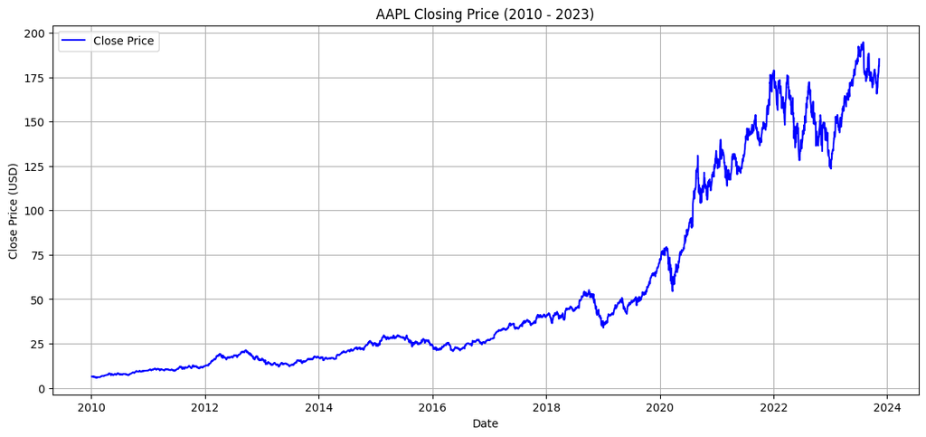

```python
# Plot the closing price over time
plt.figure(figsize=(14, 6))
plt.plot(df['Date'], df['Close'], label='Close Price', color='blue')
plt.title('AAPL Closing Price (2010 - 2023)')
plt.xlabel('Date')
plt.ylabel('Close Price (USD)')
plt.grid(True)
plt.legend()
plt.show()
```

### **Explanation**

- For this initial LSTM model, I will only focus on the `Close` price.

The `Close` price represents the final price at which AAPL traded each day.

- I reset the index so that `Date` becomes a regular column, allowing us to plot it easily.
- This line chart gives us a visual understanding of long-term price trends and volatility in Apple's stock, which helps in understanding the temporal nature of the data before passing it to an LSTM model.

## **Data Normalization with MinMaxScaler**

### **Overview**

Before feeding data into an LSTM model, it is important to normalize the input features to ensure numerical stability and faster convergence during training. In this step, I will use `MinMaxScaler` to scale the `Close` price to a range between 0 and 1.

```python
# Initialize the MinMaxScaler
scaler = MinMaxScaler(feature_range=(0, 1))

# Fit the scaler on the Close prices and transform the data
scaled_data = scaler.fit_transform(df['Close'].values.reshape(-1, 1))

# Display the first 5 scaled values
scaled_data[:5]
```

```
array([[0.00349698],
       [0.0035559 ],
       [0.00301288],
       [0.00295077],
       [0.00317371]])
```

### **Explanation**

- Neural networks are sensitive to the scale of input data. Without normalization, the model might converge slowly or not at all.
- `MinMaxScaler` rescales each value to a specified range (by default [0, 1]).
- I reshape the data to a 2D array before applying the scaler, as expected by `fit_transform`.

## **Creating Input Sequences for LSTM**

### **Overview**

LSTM models require a fixed-length sequence of previous observations as input to predict the next value in the sequence. In this step, I will create overlapping sequences of 60 days of closing prices to predict the closing price on the 61st day.

```python
# Function to create sequences of length `seq_length`
def create_sequences(data, seq_length):
    X, y = [], []
    for i in range(len(data) - seq_length):
        X.append(data[i:(i + seq_length), 0])
        y.append(data[i + seq_length, 0])
    return np.array(X), np.array(y)

# Define the sequence length (number of past days used to predict the next day)
seq_length = 60

# Create sequences using the scaled data
X, y = create_sequences(scaled_data, seq_length)

# Display the shape of the resulting arrays
print("Input shape:", X.shape)
print("Target shape:", y.shape)
```

```
Input shape: (3429, 60)
Target shape: (3429,)
```

### **Explanation**

- I define a helper function `create_sequences()` that takes the scaled data and a sequence length as input.
- For each index `i`, the function creates a sequence of `seq_length` consecutive data points to form the input `X[i]`, and the value immediately following the sequence becomes the corresponding target `y[i]`.
- The output `X` is a 2D array of shape `(num_samples, seq_length)`, and `y` is a 1D array of target values.

### **Splitting the Data into Training and Testing Sets**

### **Overview**

To evaluate model performance, the dataset is split into a training set and a testing set. The model will learn patterns from the training data and be evaluated on the unseen testing data.

```python
# Define training size: use 80% for training and 20% for testing
train_size = int(len(X) * 0.8)

# Split the input sequences and targets
X_train, X_test = X[:train_size], X[train_size:]
y_train, y_test = y[:train_size], y[train_size:]
```

### **Explanation**

- I allocate 80% of the data to the training set and the remaining 20% to the testing set using `train_size = int(len(X) * 0.8)`.
- This ensures that the model is trained on a large enough portion of the dataset to learn effectively while still allowing for a robust evaluation on the remaining data.

## **Reshaping the Input for LSTM Compatibility**

### **Overview**

The LSTM layer in Keras expects input in a 3D format: `(number of samples, sequence length, number of features)`. Since we are only using the closing price as our feature, the number of features is 1.

```python
# Reshape input arrays to match the expected input shape for LSTM: (samples, timesteps, features)
X_train = X_train.reshape(X_train.shape[0], X_train.shape[1], 1)
X_test = X_test.reshape(X_test.shape[0], X_test.shape[1], 1)
```

### **Explanation**

- The training and testing data arrays `X_train` and `X_test` are initially 2D with shape `(num_samples, sequence_length)`.
- To match LSTM's input requirements, I reshape them to 3D by adding a third dimension: `(num_samples, sequence_length, 1)`, where the last dimension represents the single feature (closing price).
- This transformation ensures that each timestep in the input sequence has one associated feature.

## **Building and Compiling the LSTM Model**

### **Overview**

This step defines the architecture of the Long Short-Term Memory (LSTM) neural network. LSTM models are particularly effective for time series prediction tasks because they retain memory over long sequences and can learn temporal dependencies.

```python
# Define the LSTM model architecture
model = Sequential([
    LSTM(50, return_sequences=True, input_shape=(seq_length, 1)),
    LSTM(50, return_sequences=False),
    Dense(25),
    Dense(1)
])

# Compile the model with Adam optimizer and Mean Squared Error loss
model.compile(
    optimizer=Adam(learning_rate=0.001),
    loss='mean_squared_error',
    metrics=['mean_absolute_error']
)
```

### **Explanation**

- The model uses two stacked `LSTM` layers:
  - The first LSTM layer has `return_sequences=True`, which allows it to pass its entire output sequence to the next LSTM layer.
  - The second LSTM layer outputs only the last hidden state (`return_sequences=False`), which feeds into the dense layers.
- A `Dense` layer with 25 units adds non-linearity and abstraction.
- The final `Dense` layer outputs a single value (the predicted closing price).
- The model is compiled with the **Adam optimizer** (adaptive learning rate) and **mean squared error (MSE)** as the loss function, suitable for regression tasks.

## **Training the LSTM Model with Early Stopping**

### **Overview**

In this step, I will train the LSTM model using early stopping to avoid overfitting. The model is trained for up to 100 epochs, but training will stop early if validation loss does not improve for 10 consecutive epochs.

```
Model: "sequential"
```

```
┏━━━━━━━━━━━━━━━━━━━━━━━━━━━━━━━━━┳━━━━━━━━━━━━━━━━━━━━━━━━┳━━━━━━━━━━━━━━━┓
┃ Layer (type)                    ┃ Output Shape           ┃       Param # ┃
┡━━━━━━━━━━━━━━━━━━━━━━━━━━━━━━━━━╇━━━━━━━━━━━━━━━━━━━━━━━━╇━━━━━━━━━━━━━━━┩
│ lstm (LSTM)                     │ (None, 60, 50)         │        10,400 │
├─────────────────────────────────┼────────────────────────┼───────────────┤
│ lstm_1 (LSTM)                   │ (None, 50)             │        20,200 │
├─────────────────────────────────┼────────────────────────┼───────────────┤
│ dense (Dense)                   │ (None, 25)             │         1,275 │
├─────────────────────────────────┼────────────────────────┼───────────────┤
│ dense_1 (Dense)                 │ (None, 1)              │            26 │
└─────────────────────────────────┴────────────────────────┴───────────────┘
```

```
 Total params: 31,901 (124.61 KB)
```

```
 Trainable params: 31,901 (124.61 KB)
```

```
 Non-trainable params: 0 (0.00 B)
```

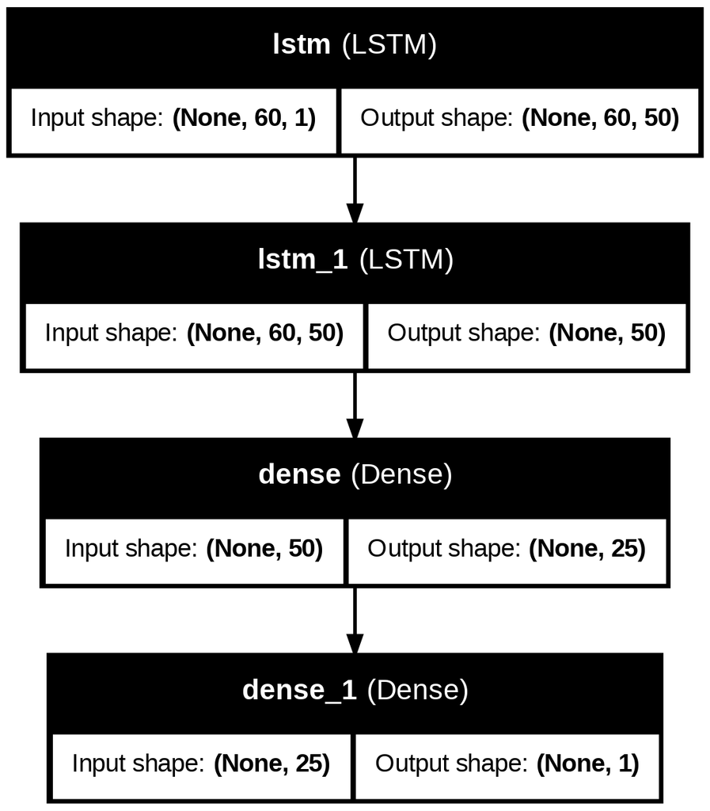

```python
from tensorflow.keras.callbacks import EarlyStopping
from tensorflow.keras.utils import plot_model

# Define early stopping to prevent overfitting
early_stop = EarlyStopping(monitor='val_loss', patience=10, restore_best_weights=True, verbose=1)

# Summarize model architecture
model.summary()

# Plot model structure to file
plot_model(model, to_file="lstm_model.png", show_shapes=True, show_layer_names=True)
```

```python
# Train the model
start_time = time.time()

history_lstm = model.fit(
    X_train,
    y_train,
    batch_size=32,
    epochs=100,
    validation_split=0.1,
    callbacks=[early_stop],
    verbose=1
)

end_time = time.time()
lstm_training_time = end_time - start_time
```

[output not shown]

[output cut: 33 more lines]

```
78/78 ━━━━━━━━━━━━━━━━━━━━ 5s 59ms/step - loss: 1.1774e-05 - mean_absolute_error: 0.0025 - val_loss: 1.9452e-04 - val_mean_absolute_error: 0.0103
78/78 ━━━━━━━━━━━━━━━━━━━━ 5s 60ms/step - loss: 9.4580e-06 - mean_absolute_error: 0.0022 - val_loss: 1.9032e-04 - val_mean_absolute_error: 0.0102
78/78 ━━━━━━━━━━━━━━━━━━━━ 4s 52ms/step - loss: 8.1736e-06 - mean_absolute_error: 0.0020 - val_loss: 1.8461e-04 - val_mean_absolute_error: 0.0100
78/78 ━━━━━━━━━━━━━━━━━━━━ 5s 69ms/step - loss: 9.3511e-06 - mean_absolute_error: 0.0022 - val_loss: 2.4321e-04 - val_mean_absolute_error: 0.0119
78/78 ━━━━━━━━━━━━━━━━━━━━ 4s 53ms/step - loss: 1.4383e-05 - mean_absolute_error: 0.0028 - val_loss: 2.5904e-04 - val_mean_absolute_error: 0.0123
78/78 ━━━━━━━━━━━━━━━━━━━━ 5s 53ms/step - loss: 8.8828e-06 - mean_absolute_error: 0.0021 - val_loss: 2.5290e-04 - val_mean_absolute_error: 0.0121
78/78 ━━━━━━━━━━━━━━━━━━━━ 6s 66ms/step - loss: 8.6916e-06 - mean_absolute_error: 0.0021 - val_loss: 1.9665e-04 - val_mean_absolute_error: 0.0104
78/78 ━━━━━━━━━━━━━━━━━━━━ 4s 52ms/step - loss: 8.0234e-06 - mean_absolute_error: 0.0019 - val_loss: 1.9691e-04 - val_mean_absolute_error: 0.0104
78/78 ━━━━━━━━━━━━━━━━━━━━ 6s 69ms/step - loss: 8.4768e-06 - mean_absolute_error: 0.0021 - val_loss: 2.6043e-04 - val_mean_absolute_error: 0.0124
78/78 ━━━━━━━━━━━━━━━━━━━━ 9s 53ms/step - loss: 9.7716e-06 - mean_absolute_error: 0.0022 - val_loss: 2.0648e-04 - val_mean_absolute_error: 0.0107
78/78 ━━━━━━━━━━━━━━━━━━━━ 5s 69ms/step - loss: 8.0131e-06 - mean_absolute_error: 0.0020 - val_loss: 1.8861e-04 - val_mean_absolute_error: 0.0101
78/78 ━━━━━━━━━━━━━━━━━━━━ 4s 52ms/step - loss: 1.0793e-05 - mean_absolute_error: 0.0024 - val_loss: 1.8893e-04 - val_mean_absolute_error: 0.0101
78/78 ━━━━━━━━━━━━━━━━━━━━ 4s 53ms/step - loss: 9.1733e-06 - mean_absolute_error: 0.0022 - val_loss: 1.9897e-04 - val_mean_absolute_error: 0.0105
Epoch 86: early stopping
Restoring model weights from the end of the best epoch: 76.
```

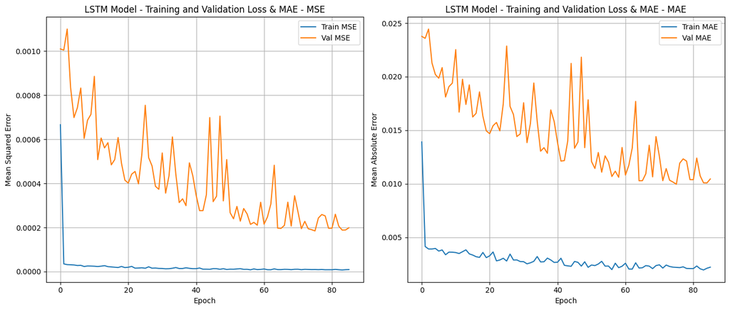

```python
# Training history plot showing both MSE and MAE
def plot_training_history(history, title):
    plt.figure(figsize=(14, 6))

    # Plot MSE (Loss)
    plt.subplot(1, 2, 1)
    plt.plot(history.history['loss'], label='Train MSE')
    plt.plot(history.history['val_loss'], label='Val MSE')
    plt.title(f"{title} - MSE")
    plt.xlabel('Epoch')
    plt.ylabel('Mean Squared Error')
    plt.legend()
    plt.grid(True)

    # Plot MAE
    plt.subplot(1, 2, 2)
    plt.plot(history.history['mean_absolute_error'], label='Train MAE')
    plt.plot(history.history['val_mean_absolute_error'], label='Val MAE')
    plt.title(f"{title} - MAE")
    plt.xlabel('Epoch')
    plt.ylabel('Mean Absolute Error')
    plt.legend()
    plt.grid(True)

    plt.tight_layout()
    plt.show()


# Plot the history for LSTM model
plot_training_history(history_lstm, "LSTM Model - Training and Validation Loss & MAE")
```

### **Explanation**

- `EarlyStopping` monitors the validation loss and stops training when it fails to improve for 10 epochs. The best weights are automatically restored.
- The model is trained using:
  - `batch_size = 32`
  - `epochs = 100`
  - `validation_split = 0.1` to reserve 10% of the training data for validation
- After training, a line plot is generated to visualize the training and validation loss curves across epochs.

## **Making Predictions and Evaluating Model Performance**

### **Overview**

In this step, I use the trained LSTM model to make predictions on the test dataset. I then inverse-transform both the predictions and the actual test values back to the original dollar scale using the fitted `MinMaxScaler`. I evaluate performance using the Root Mean Squared Error (RMSE) and Mean Absolute Error (MAE).

```python
# Make predictions on the test set
start_time = time.time()

predictions = model.predict(X_test)

end_time = time.time()
lstm_prediction_time = end_time - start_time

# Invert scaling to get predicted and actual values in original price scale
predictions = scaler.inverse_transform(predictions)
y_test_actual = scaler.inverse_transform(y_test.reshape(-1, 1))
```

```
22/22 ━━━━━━━━━━━━━━━━━━━━ 1s 45ms/step
```

```python
# Compute Root Mean Squared Error & Mean Absolute Error
lstm_rmse = np.sqrt(np.mean((predictions - y_test_actual) ** 2))
lstm_mae = np.mean(np.abs(predictions - y_test_actual))

print(f"LSTM Model RMSE: {lstm_rmse:.4f}")
print(f"LSTM Model MAE:  {lstm_mae:.4f}")
print(f"LSTM Training Time: {lstm_training_time:.2f} seconds")
print(f"LSTM Prediction Time: {lstm_prediction_time:.2f} seconds")
```

```
LSTM Model RMSE: 2.7212
LSTM Model MAE:  2.0651
LSTM Training Time: 504.51 seconds
LSTM Prediction Time: 2.67 seconds
```

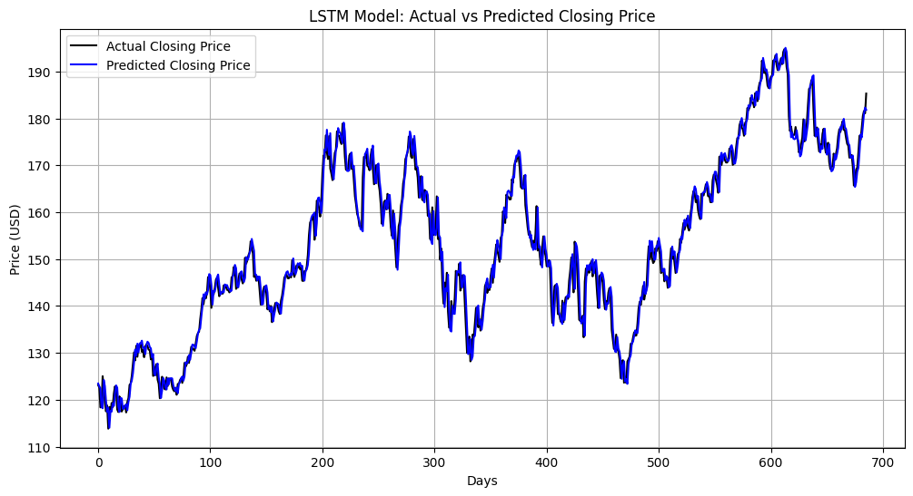

```python
# Plot the actual vs predicted closing prices
plt.figure(figsize=(12, 6))
plt.plot(y_test_actual, label='Actual Closing Price', color='black')
plt.plot(predictions, label='Predicted Closing Price', color='blue')
plt.title('LSTM Model: Actual vs Predicted Closing Price')
plt.xlabel('Days')
plt.ylabel('Price (USD)')
plt.legend()
plt.grid(True)
plt.show()
```

### **Explanation**

- The LSTM model outputs predictions in the same normalized scale as the input. To compare with the actual prices, I reverse the scaling using `scaler.inverse_transform`.
- I evaluate model performance using two regression metrics:
  - **Root Mean Squared Error (RMSE)**: Emphasizes large errors by squaring them.
  - **Mean Absolute Error (MAE)**: Provides an interpretable average error magnitude in dollars.
- Both metrics give insight into the prediction accuracy of the model.
- Finally, I visualize the actual vs. predicted closing prices over time to assess how well the model tracks real stock movements.

### **Results**

- An **RMSE of 2.7212** shows that the LSTM model performs reasonably well in limiting large prediction errors, demonstrating competence in modeling overall price behavior.
- An **MAE of 2.0651** confirms strong average accuracy, with predictions deviating by just over $2 per day — making it a solid performer for general forecasting tasks.
- **Training Time:** 504.51 seconds. While LSTM provides decent accuracy, it is the **slow to train**, which may be a limiting factor in resource-constrained or real-time applications.
- **Prediction Time:** 2.67 seconds, which is acceptable but not optimal for low-latency deployment.
- The plot shows that the LSTM model closely follows both long-term price trends and short-term variations. However, its higher computational cost compared to GRU models may outweigh its prediction performance in certain business use cases.

# **2. GRU Model** - (baseline: only closing price)

**Overview:**

- This section implements a baseline GRU (Gated Recurrent Unit) model using only the **closing price** as input.
- The architecture is designed to capture temporal dependencies in stock prices by leveraging the memory and gating mechanisms of GRUs.

**Motivation:**

- GRUs are a simplified alternative to LSTMs with fewer parameters and faster training time.
- They are well-suited for time series data and are capable of modeling long-term dependencies.
- This baseline provides a point of comparison for evaluating the impact of additional features and architectural enhancements in later sections.

**Implementation:**

- The input consists of sequences of 60 previous closing prices.
- The model architecture includes:
  - Two stacked GRU layers with 50 units each
  - A dense layer with 25 units for intermediate transformation
  - A final dense output layer with 1 unit for predicting the next closing price
- The model is compiled with:
  - **Mean Squared Error (MSE)** loss function
  - **Mean Absolute Error (MAE)** as an evaluation metric
  - **Adam optimizer** with a learning rate of 0.001
- Early stopping is used to prevent overfitting.

```python
# Import GRU layer from Keras
from tensorflow.keras.layers import GRU
```

## **Defining and Compiling the GRU Model**

### **Overview**

This step defines the architecture of the Gated Recurrent Unit (GRU) model. GRUs are an efficient variant of LSTMs with fewer parameters and simplified gate structures, often leading to faster training and comparable accuracy.

```python
# Define the GRU model architecture
gru_model = Sequential([
    GRU(50, return_sequences=True, input_shape=(seq_length, 1)),
    GRU(50, return_sequences=False),
    Dense(25),
    Dense(1)
])

# Compile the GRU model with MSE loss and MAE metric
gru_model.compile(
    optimizer=Adam(learning_rate=0.001),
    loss='mean_squared_error',
    metrics=['mean_absolute_error']
)
```

### **Explanation**

- The model structure is analogous to the LSTM model:
  - Two stacked `GRU` layers, with the first returning sequences and the second not.
  - A dense layer with 25 units to introduce non-linearity.
  - A final dense layer with a single neuron to output the predicted stock price.
- The model is compiled with:
  - `mean_squared_error` as the loss function
  - `mean_absolute_error` (MAE) as an additional metric for evaluation
- GRUs retain the ability to model temporal dependencies but are faster to train due to fewer gates (reset and update).

## **Training the GRU Model with Early Stopping**

### **Overview**

In this step, I train the GRU model using the same early stopping strategy used for the LSTM model. The training process will automatically stop if the validation loss does not improve for 10 consecutive epochs. The model structure is also saved to a file for reference.

```
Model: "sequential_1"
```

```
┏━━━━━━━━━━━━━━━━━━━━━━━━━━━━━━━━━┳━━━━━━━━━━━━━━━━━━━━━━━━┳━━━━━━━━━━━━━━━┓
┃ Layer (type)                    ┃ Output Shape           ┃       Param # ┃
┡━━━━━━━━━━━━━━━━━━━━━━━━━━━━━━━━━╇━━━━━━━━━━━━━━━━━━━━━━━━╇━━━━━━━━━━━━━━━┩
│ gru (GRU)                       │ (None, 60, 50)         │         7,950 │
├─────────────────────────────────┼────────────────────────┼───────────────┤
│ gru_1 (GRU)                     │ (None, 50)             │        15,300 │
├─────────────────────────────────┼────────────────────────┼───────────────┤
│ dense_2 (Dense)                 │ (None, 25)             │         1,275 │
├─────────────────────────────────┼────────────────────────┼───────────────┤
│ dense_3 (Dense)                 │ (None, 1)              │            26 │
└─────────────────────────────────┴────────────────────────┴───────────────┘
```

```
 Total params: 24,551 (95.90 KB)
```

```
 Trainable params: 24,551 (95.90 KB)
```

```
 Non-trainable params: 0 (0.00 B)
```

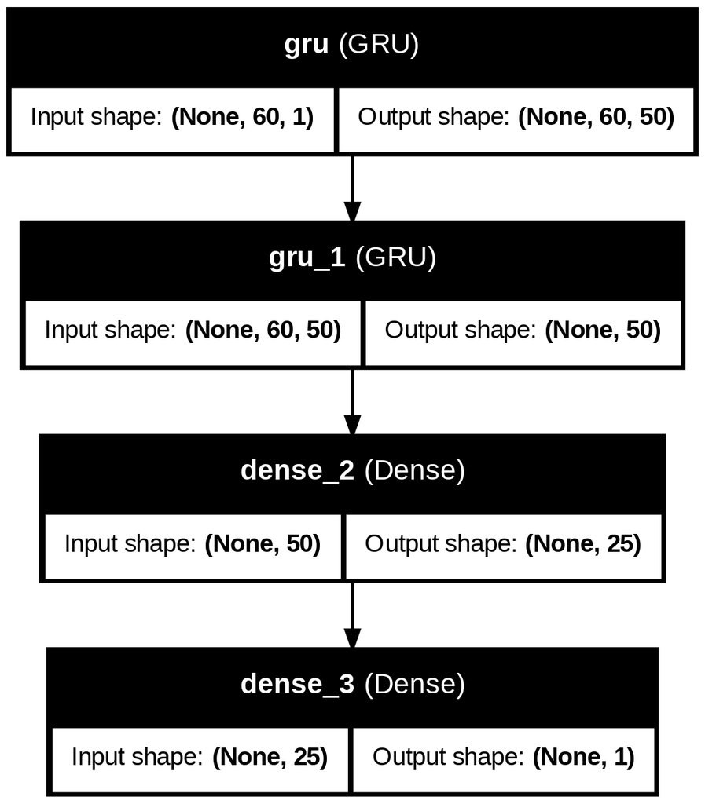

```python
# Display the GRU model architecture
gru_model.summary()

# Save the model architecture diagram
plot_model(gru_model, to_file="gru_model.png", show_shapes=True, show_layer_names=True)
```

```python
# Train the GRU model
start_time = time.time()

history_gru = gru_model.fit(
    X_train,
    y_train,
    batch_size=32,
    epochs=100,
    validation_split=0.1,
    callbacks=[early_stop],
    verbose=1
)

end_time = time.time()
gru_training_time = end_time - start_time
```

[output not shown]

[output cut: 17 more lines]

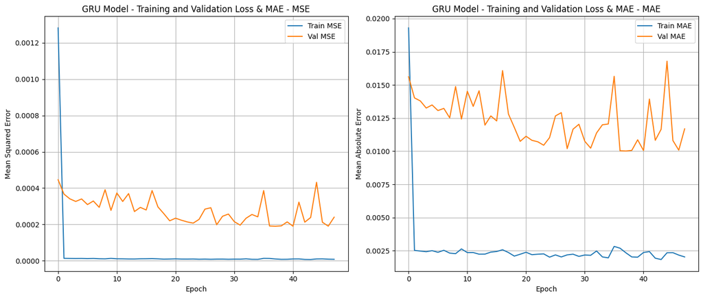

```python
# Plot training history for the GRU model
plot_training_history(history_gru, "GRU Model - Training and Validation Loss & MAE")
```

### **Explanation**

- I use the same `EarlyStopping` callback to prevent overfitting and save computation time.
- Training runs for up to 100 epochs, using 10% of the training data for validation (`validation_split=0.1`).
- After training, I visualize both:
  - `loss` vs. `val_loss` (Mean Squared Error)
  - `mean_absolute_error` vs. `val_mean_absolute_error`
- This allows me to track both the magnitude and variance of prediction errors during training.

## **Making Predictions and Evaluating GRU Model Performance**

### **Overview**

After training, I evaluate the GRU model on the test dataset using RMSE and MAE. I also visualize the predicted vs. actual closing prices to qualitatively assess the model's performance.

```python
# Generate predictions with the GRU model
start_time = time.time()

gru_predictions = gru_model.predict(X_test)

end_time = time.time()
gru_prediction_time = end_time - start_time

# Invert scaling to get dollar values
gru_predictions = scaler.inverse_transform(gru_predictions)
y_test_actual_gru = scaler.inverse_transform(y_test.reshape(-1, 1))
```

```
22/22 ━━━━━━━━━━━━━━━━━━━━ 1s 35ms/step
```

```python
# Calculate RMSE and MAE
gru_rmse = np.sqrt(np.mean((gru_predictions - y_test_actual_gru) ** 2))
gru_mae = np.mean(np.abs(gru_predictions - y_test_actual_gru))

print(f"GRU Model RMSE: {gru_rmse:.4f}")
print(f"GRU Model MAE:  {gru_mae:.4f}")
print(f"GRU Training Time: {gru_training_time:.2f} seconds")
print(f"GRU Prediction Time: {gru_prediction_time:.2f} seconds")
```

```
GRU Model RMSE: 2.8678
GRU Model MAE:  2.1909
GRU Training Time: 399.99 seconds
GRU Prediction Time: 1.26 seconds
```

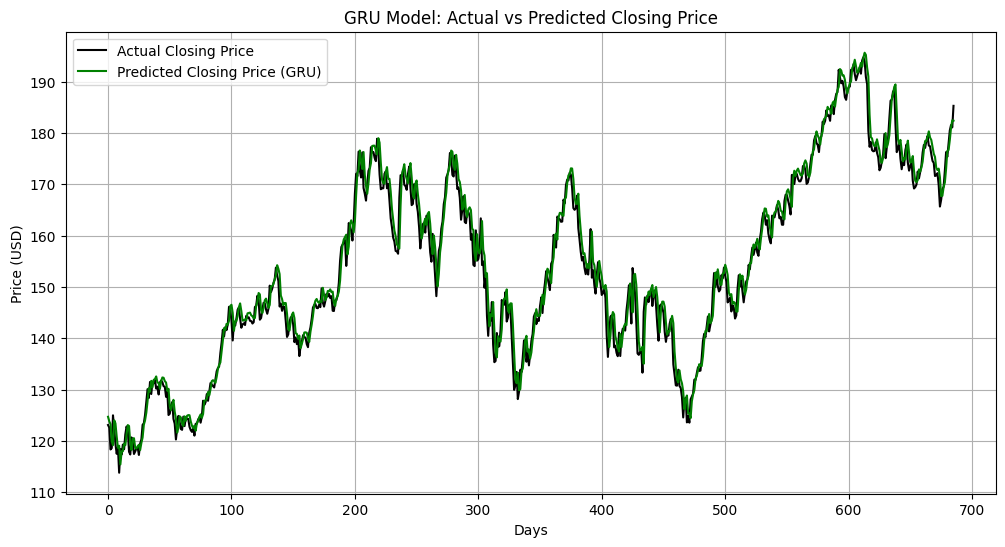

```python
# Plot actual vs predicted closing prices for the GRU model
plt.figure(figsize=(12, 6))
plt.plot(y_test_actual_gru, label='Actual Closing Price', color='black')
plt.plot(gru_predictions, label='Predicted Closing Price (GRU)', color='green')
plt.title('GRU Model: Actual vs Predicted Closing Price')
plt.xlabel('Days')
plt.ylabel('Price (USD)')
plt.legend()
plt.grid(True)
plt.show()
```

### **Explanation**

- I use the trained GRU model to predict closing prices on the test data.
- Both the predictions and the true test labels are inverse-transformed using the previously fitted `MinMaxScaler` to obtain actual dollar values.
- Two evaluation metrics are computed:
  - **Root Mean Squared Error (RMSE)**: Penalizes large errors more heavily
  - **Mean Absolute Error (MAE)**: Gives average absolute error in units of dollars
- I then plot the actual vs. predicted prices to inspect how well the model captures market trends.

# **3. GRU Model with Additional Features** - (closing price and volume)

**Overview:**

- This section extends the baseline GRU model by including an additional input feature: daily **trading volume**, alongside the **closing price**.
- My hypothesis is that incorporating volume can provide the model with richer contextual information about market behavior, potentially improving prediction accuracy.

**Motivation:**

- Trading volume is often used by analysts to confirm price trends, momentum, or volatility.
- Volume spikes can precede or coincide with significant price movements.
- Including volume allows the model to learn complex interactions between price and trading activity over time.

**Implementation (Key Changes):**

- The input feature set is expanded to include both `Close` and `Volume` columns.
- The input shape of the GRU model is updated to reflect two features per timestep: `(seq_length, 2)`.
- The sequence generation function is modified to return multi-dimensional feature sequences.
- The model architecture remains the same in terms of GRU and dense layers.

## **Re-import and Expand Dataset to Include Volume**

```python
# Re-download full dataset with Close and Volume columns
data = yf.download("AAPL", start="2010-01-01", end="2023-11-13")

# Keep only 'Close' and 'Volume', then reset index
df_multi = data[['Close', 'Volume']].reset_index()

# Display the first few rows
df_multi.head()
```

```
[*********************100%***********************]  1 of 1 completed
```

| Price Ticker | Date | Close AAPL | Volume AAPL |
| --- | --- | --- | --- |
| 0 | 2010-01-04 | 6.440330 | 493729600 |
| 1 | 2010-01-05 | 6.451466 | 601904800 |
| 2 | 2010-01-06 | 6.348846 | 552160000 |
| 3 | 2010-01-07 | 6.337109 | 477131200 |
| 4 | 2010-01-08 | 6.379239 | 447610800 |

### **Explanation**

- Stock volume indicates how much of a security was traded during a given period and is often used to confirm trends or identify momentum shifts.
- By including volume in the model, I allow it to learn relationships between both price and trading activity.
- I reset the index to retain the `Date` column and isolate the relevant features for modeling.

## **Normalizing Close and Volume Features**

### **Overview**

Before feeding the multi-feature data into the GRU model, I normalize both the `Close` and `Volume` columns using `MinMaxScaler`. This ensures that both features contribute equally during training and prevents the model from being biased by larger numeric scales.

```python
# Initialize a new MinMaxScaler and scale both features
multi_scaler = MinMaxScaler()
scaled_multi_data = multi_scaler.fit_transform(df_multi[['Close', 'Volume']])

# Display the first few rows of the scaled result
scaled_multi_data[:5]
```

```
array([[0.00349698, 0.24993861],
       [0.0035559 , 0.30842624],
       [0.00301288, 0.28153047],
       [0.00295077, 0.24096427],
       [0.00317371, 0.22500332]])
```

### **Explanation**

- `MinMaxScaler` rescales both columns to the range [0, 1].
- This is critical because `Volume` values are typically several orders of magnitude larger than `Close` prices.
- Without normalization, the model could incorrectly attribute more importance to volume simply due to its scale.
- The scaled result is a 2D NumPy array with shape `(n_samples, 2)`, where each row contains `[scaled_close, scaled_volume]`.

## **Creating Sequences for Multi-Feature GRU Model**

### **Overview**

In this step, I update the sequence creation function to handle multi-feature input. Each input sequence now includes both `Close` and `Volume` for every timestep. However, the prediction target remains the `Close` price.

```python
# Updated sequence generation function for multi-feature input
def create_multi_feature_sequences(data, seq_length):
    X, y = [], []
    for i in range(len(data) - seq_length):
        X.append(data[i:(i + seq_length), :])  # All features for each timestep
        y.append(data[i + seq_length, 0])      # Target is still the 'Close' price
    return np.array(X), np.array(y)

# Define sequence length
seq_length = 60

# Generate sequences
X_multi, y_multi = create_multi_feature_sequences(scaled_multi_data, seq_length)

# Display shapes
print("Input shape:", X_multi.shape)
print("Target shape:", y_multi.shape)
```

```
Input shape: (3429, 60, 2)
Target shape: (3429,)
```

### **Explanation**

- The updated function `create_multi_feature_sequences()` accepts the full 2D scaled dataset (containing both features).
- Each sequence is a 2D array of shape `(seq_length, 2)` — one row per day, two values per row.
- The target value `y[i]` remains the `Close` price on the day following each sequence (`data[i + seq_length, 0]`).
- The returned `X_multi` is a 3D array of shape `(num_samples, 60, 2)`, and `y_multi` is a 1D array of shape `(num_samples,)`.

## **Splitting Multi-Feature Data into Training and Testing Sets**

### **Overview**

Now that the multi-feature sequences are prepared, I split the dataset into training and testing sets. This allows me to train the GRU model on 80% of the data and evaluate it on the remaining 20%.

```python
# Define training set size (80%)
train_size = int(len(X_multi) * 0.8)

# Split sequences and targets into training and testing sets
X_train_multi, X_test_multi = X_multi[:train_size], X_multi[train_size:]
y_train_multi, y_test_multi = y_multi[:train_size], y_multi[train_size:]
```

### **Explanation**

- I calculate the training set size as 80% of the total number of sequences.
- The input sequences (`X_multi`) and corresponding targets (`y_multi`) are split accordingly.
- This ensures consistency with the LSTM and baseline GRU models for a fair performance comparison.

## **Defining and Training the GRU Model with Close and Volume Features**

### **Overview**

In this step, I build and train a GRU model that uses both `Close` and `Volume` as input features for each timestep. This provides the model with more contextual information during training and may improve predictive performance.

```python
# Define the GRU model to handle two input features per timestep
gru_model_multi = Sequential([
    GRU(50, return_sequences=True, input_shape=(seq_length, 2)),
    GRU(50, return_sequences=False),
    Dense(25),
    Dense(1)
])

# Compile the model with MSE loss and MAE metric
gru_model_multi.compile(
    optimizer=Adam(learning_rate=0.001),
    loss='mean_squared_error',
    metrics=['mean_absolute_error']
)
```

```
Model: "sequential_2"
```

```
┏━━━━━━━━━━━━━━━━━━━━━━━━━━━━━━━━━┳━━━━━━━━━━━━━━━━━━━━━━━━┳━━━━━━━━━━━━━━━┓
┃ Layer (type)                    ┃ Output Shape           ┃       Param # ┃
┡━━━━━━━━━━━━━━━━━━━━━━━━━━━━━━━━━╇━━━━━━━━━━━━━━━━━━━━━━━━╇━━━━━━━━━━━━━━━┩
│ gru_2 (GRU)                     │ (None, 60, 50)         │         8,100 │
├─────────────────────────────────┼────────────────────────┼───────────────┤
│ gru_3 (GRU)                     │ (None, 50)             │        15,300 │
├─────────────────────────────────┼────────────────────────┼───────────────┤
│ dense_4 (Dense)                 │ (None, 25)             │         1,275 │
├─────────────────────────────────┼────────────────────────┼───────────────┤
│ dense_5 (Dense)                 │ (None, 1)              │            26 │
└─────────────────────────────────┴────────────────────────┴───────────────┘
```

```
 Total params: 24,701 (96.49 KB)
```

```
 Trainable params: 24,701 (96.49 KB)
```

```
 Non-trainable params: 0 (0.00 B)
```

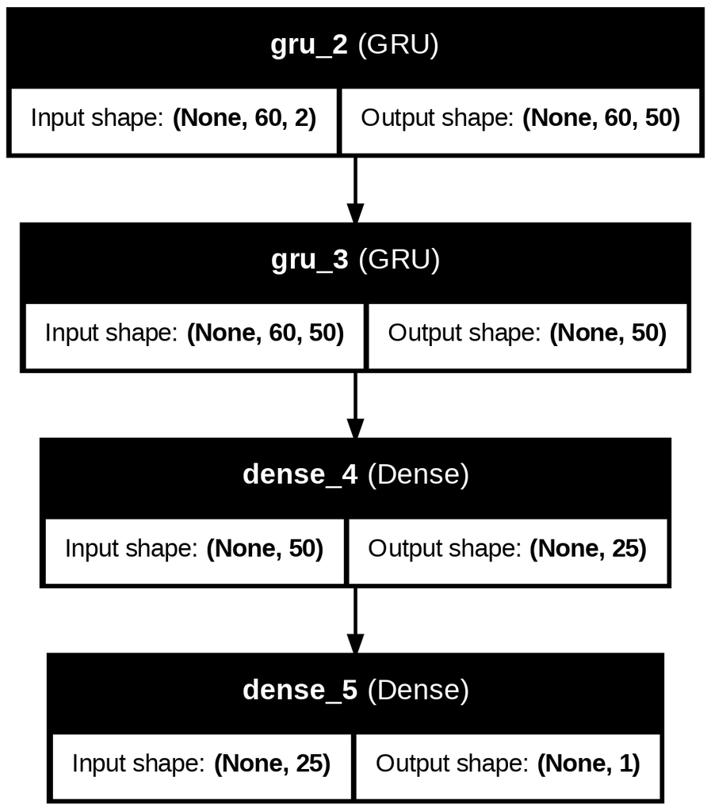

```python
# Display the model architecture
gru_model_multi.summary()

# Save the model structure to file
plot_model(gru_model_multi, to_file="gru_model_multi.png", show_shapes=True, show_layer_names=True)
```

```python
# Train the multi-feature GRU model
start_time = time.time()

history_gru_multi = gru_model_multi.fit(
    X_train_multi,
    y_train_multi,
    batch_size=32,
    epochs=100,
    validation_split=0.1,
    callbacks=[early_stop],
    verbose=1
)

end_time = time.time()
gru_multi_training_time = end_time - start_time
```

[output not shown]

[output cut: 19 more lines]

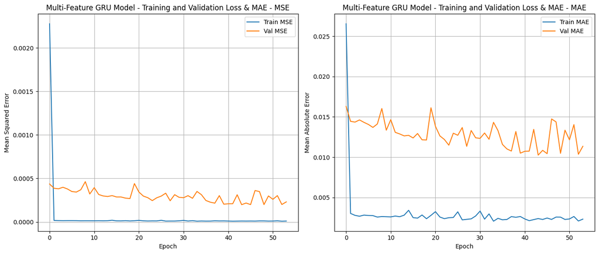

```python
# Plot training history
plot_training_history(history_gru_multi, "Multi-Feature GRU Model - Training and Validation Loss & MAE")
```

### **Explanation**

- The architecture is the same as the earlier GRU model but with a modified input shape: `(sequence_length=60, features=2)`.
- The model is compiled with:
  - `mean_squared_error` as the loss function
  - `mean_absolute_error` as an additional evaluation metric
- Training uses `EarlyStopping` to avoid overfitting and save compute time.
- The training and validation loss/MAE are plotted to visually assess convergence and generalization.

## **Evaluating the Multi-Feature GRU Model**

### **Overview**

After training the GRU model on both `Close` and `Volume` data, I evaluate its performance on the test set using RMSE and MAE. I also visualize the actual vs predicted prices to assess accuracy and temporal alignment.

```python
# Generate predictions using the multi-feature GRU model
start_time = time.time()

gru_multi_predictions = gru_model_multi.predict(X_test_multi)

end_time = time.time()
gru_multi_prediction_time = end_time - start_time

# To inverse-transform, we must concatenate with dummy volume values
# since the scaler expects 2D input with two features
dummy_volume = np.zeros_like(gru_multi_predictions)
combined_predictions = np.concatenate((gru_multi_predictions, dummy_volume), axis=1)
combined_actuals = np.concatenate((y_test_multi.reshape(-1, 1), dummy_volume), axis=1)

# Invert scaling to recover original closing prices
multi_predictions_unscaled = multi_scaler.inverse_transform(combined_predictions)[:, 0]
y_test_unscaled_multi = multi_scaler.inverse_transform(combined_actuals)[:, 0]
```

```
22/22 ━━━━━━━━━━━━━━━━━━━━ 1s 37ms/step
```

```python
# Calculate RMSE and MAE for multi-feature GRU
multi_rmse = np.sqrt(np.mean((multi_predictions_unscaled - y_test_unscaled_multi) ** 2))
multi_mae = np.mean(np.abs(multi_predictions_unscaled - y_test_unscaled_multi))

print(f"Multi-Feature GRU RMSE: {multi_rmse:.4f}")
print(f"Multi-Feature GRU MAE:  {multi_mae:.4f}")
print(f"Multi-Feature GRU Training Time: {gru_multi_training_time:.2f} seconds")
print(f"Multi-Feature GRU Prediction Time: {gru_multi_prediction_time:.2f} seconds")
```

```
Multi-Feature GRU RMSE: 3.1602
Multi-Feature GRU MAE:  2.4467
Multi-Feature GRU Training Time: 497.95 seconds
Multi-Feature GRU Prediction Time: 2.68 seconds
```

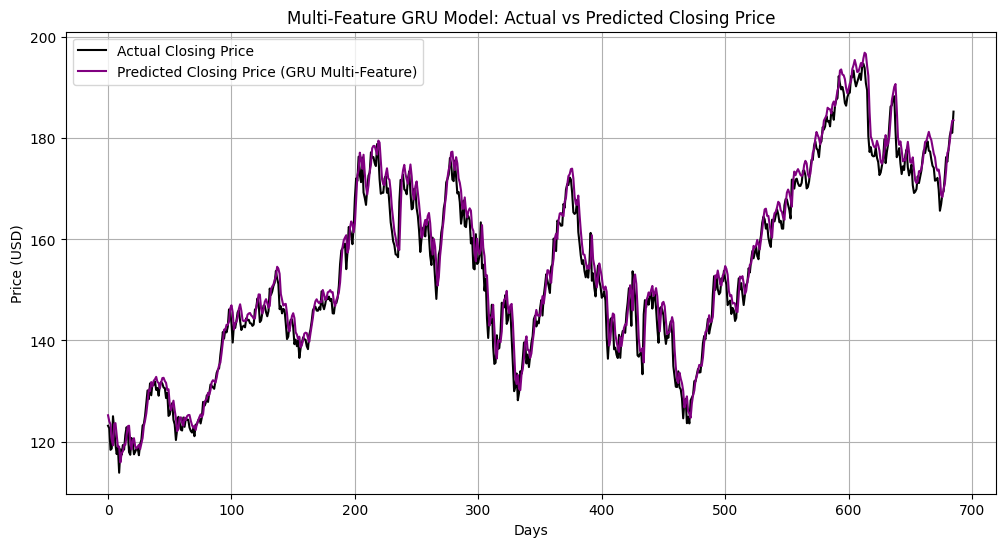

```python
# Plot actual vs predicted closing prices for multi-feature GRU
plt.figure(figsize=(12, 6))
plt.plot(y_test_unscaled_multi, label='Actual Closing Price', color='black')
plt.plot(multi_predictions_unscaled, label='Predicted Closing Price (GRU Multi-Feature)', color='purple')
plt.title('Multi-Feature GRU Model: Actual vs Predicted Closing Price')
plt.xlabel('Days')
plt.ylabel('Price (USD)')
plt.legend()
plt.grid(True)
plt.show()
```

### **Explanation**

- I use the trained model to generate predictions from the multi-feature test data.
- Since the scaler expects two features (`Close`, `Volume`) for inverse transformation, I append a dummy volume column of zeros.
- The inverse-transformed predictions and targets are then compared using:
  - **Root Mean Squared Error (RMSE)**: Emphasizes large errors
  - **Mean Absolute Error (MAE)**: Measures average prediction error in dollars
- Finally, I plot the actual vs predicted prices to assess how closely the model tracks real movements.

### **Results**

- An **RMSE of 3.1602** shows a slight increase in error compared to the baseline GRU model, suggesting that the addition of `Volume` did not consistently improve large-error minimization in this run.
- An **MAE of 2.4467** indicates reasonable average accuracy, though it is slightly worse than the single-feature GRU, suggesting that volume may have introduced some noise or model complexity.
- **Training Time:** 497.95 seconds — longer than the baseline GRU, likely due to the increase in input dimensionality.
- **Prediction Time:** 2.68 seconds — notably slower than single-feature GRU, which may impact deployment if real-time response is needed.
- The prediction plot still demonstrates a strong fit between actual and predicted prices. The inclusion of volume appears to maintain overall accuracy and trend fidelity, but at the cost of increased training time and marginally reduced precision.

# **4. Modified GRU Model** - (different activation functions)

**Overview:**

- In this section, I extend the enhanced GRU model (which uses both `Close` and `Volume` as input features) by experimenting with different activation functions in the GRU and dense layers.
- The goal is to evaluate how the choice of activation function impacts model learning dynamics and predictive accuracy.

Each model uses the same architecture and training configuration, with only the activation function altered:

- **ReLU (Rectified Linear Unit)**
  - Used in GRU and dense layers. May improve gradient flow and avoid saturation.
- **Leaky ReLU**
  - Applied in the dense layer. Allows small negative gradients to avoid "dying ReLU" problem.
- **ELU (Exponential Linear Unit)**
  - Used in both GRU and dense layers. Smooth for negative inputs, reducing bias shift.
- **SELU (Scaled ELU)**
  - Self-normalizing variant of ELU. Requires LeCunNormal initialization for stability.

## **4.1 GRU Model with ReLU Activation**

### **Overview**

In this step, I experiment with replacing the default `tanh` activation in the GRU layers with `ReLU`. This change can potentially improve gradient flow and model convergence, especially when handling features with non-negative or wide dynamic ranges.

```python
# Define a GRU model using ReLU for the hidden state activation
gru_model_relu = Sequential([
    GRU(50, return_sequences=True, input_shape=(seq_length, 2),
         activation='relu', recurrent_activation='sigmoid'),
    GRU(50, return_sequences=False,
         activation='relu', recurrent_activation='sigmoid'),
    Dense(25, activation='relu'),
    Dense(1)
])

# Compile the model
gru_model_relu.compile(
    optimizer=Adam(learning_rate=0.001),
    loss='mean_squared_error',
    metrics=['mean_absolute_error']
)
```

```
Model: "sequential_3"
```

```
┏━━━━━━━━━━━━━━━━━━━━━━━━━━━━━━━━━┳━━━━━━━━━━━━━━━━━━━━━━━━┳━━━━━━━━━━━━━━━┓
┃ Layer (type)                    ┃ Output Shape           ┃       Param # ┃
┡━━━━━━━━━━━━━━━━━━━━━━━━━━━━━━━━━╇━━━━━━━━━━━━━━━━━━━━━━━━╇━━━━━━━━━━━━━━━┩
│ gru_4 (GRU)                     │ (None, 60, 50)         │         8,100 │
├─────────────────────────────────┼────────────────────────┼───────────────┤
│ gru_5 (GRU)                     │ (None, 50)             │        15,300 │
├─────────────────────────────────┼────────────────────────┼───────────────┤
│ dense_6 (Dense)                 │ (None, 25)             │         1,275 │
├─────────────────────────────────┼────────────────────────┼───────────────┤
│ dense_7 (Dense)                 │ (None, 1)              │            26 │
└─────────────────────────────────┴────────────────────────┴───────────────┘
```

```
 Total params: 24,701 (96.49 KB)
```

```
 Trainable params: 24,701 (96.49 KB)
```

```
 Non-trainable params: 0 (0.00 B)
```

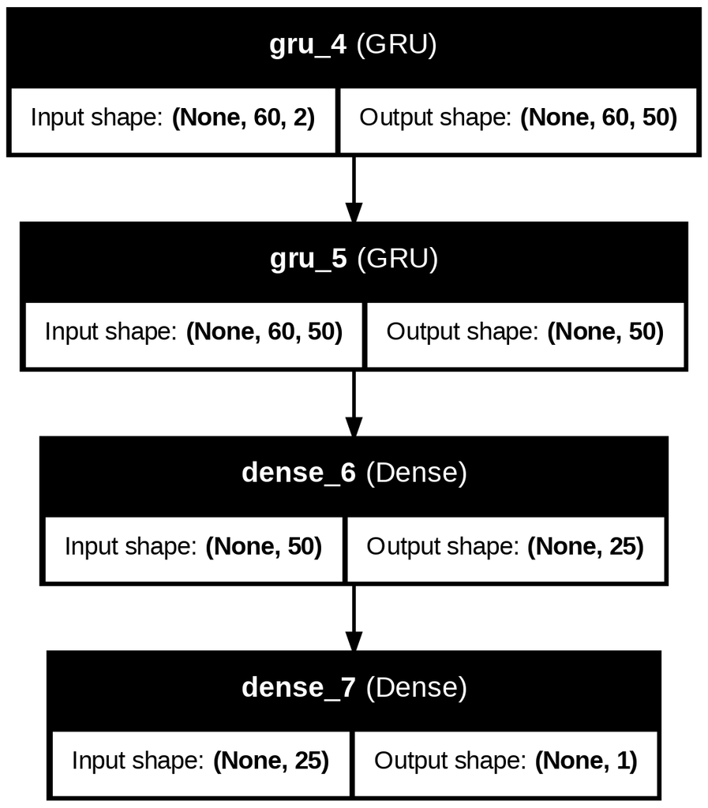

```python
# Summarize and save the ReLU model structure
gru_model_relu.summary()
plot_model(gru_model_relu, to_file="gru_model_relu.png", show_shapes=True, show_layer_names=True)
```

```python
# Train the ReLU-activated GRU model
start_time = time.time()

history_gru_relu = gru_model_relu.fit(
    X_train_multi,
    y_train_multi,
    batch_size=32,
    epochs=100,
    validation_split=0.1,
    callbacks=[early_stop],
    verbose=1
)

end_time = time.time()
gru_relu_training_time = end_time - start_time
```

```
78/78 ━━━━━━━━━━━━━━━━━━━━ 13s 101ms/step - loss: 0.0032 - mean_absolute_error: 0.0377 - val_loss: 0.0033 - val_mean_absolute_error: 0.0449
78/78 ━━━━━━━━━━━━━━━━━━━━ 8s 75ms/step - loss: 8.4530e-05 - mean_absolute_error: 0.0073 - val_loss: 0.0019 - val_mean_absolute_error: 0.0341
78/78 ━━━━━━━━━━━━━━━━━━━━ 10s 73ms/step - loss: 3.2004e-05 - mean_absolute_error: 0.0044 - val_loss: 0.0030 - val_mean_absolute_error: 0.0425
78/78 ━━━━━━━━━━━━━━━━━━━━ 7s 85ms/step - loss: 1.9967e-05 - mean_absolute_error: 0.0033 - val_loss: 0.0026 - val_mean_absolute_error: 0.0390
78/78 ━━━━━━━━━━━━━━━━━━━━ 6s 71ms/step - loss: 2.0007e-05 - mean_absolute_error: 0.0034 - val_loss: 0.0025 - val_mean_absolute_error: 0.0382
78/78 ━━━━━━━━━━━━━━━━━━━━ 10s 74ms/step - loss: 1.7220e-05 - mean_absolute_error: 0.0030 - val_loss: 0.0026 - val_mean_absolute_error: 0.0393
78/78 ━━━━━━━━━━━━━━━━━━━━ 8s 99ms/step - loss: 2.1244e-05 - mean_absolute_error: 0.0034 - val_loss: 0.0026 - val_mean_absolute_error: 0.0388
78/78 ━━━━━━━━━━━━━━━━━━━━ 6s 73ms/step - loss: 1.5875e-05 - mean_absolute_error: 0.0029 - val_loss: 0.0027 - val_mean_absolute_error: 0.0398
78/78 ━━━━━━━━━━━━━━━━━━━━ 7s 87ms/step - loss: 1.7749e-05 - mean_absolute_error: 0.0032 - val_loss: 0.0029 - val_mean_absolute_error: 0.0418
78/78 ━━━━━━━━━━━━━━━━━━━━ 6s 72ms/step - loss: 1.3928e-05 - mean_absolute_error: 0.0027 - val_loss: 0.0032 - val_mean_absolute_error: 0.0438
78/78 ━━━━━━━━━━━━━━━━━━━━ 10s 73ms/step - loss: 2.2061e-05 - mean_absolute_error: 0.0037 - val_loss: 0.0036 - val_mean_absolute_error: 0.0472
78/78 ━━━━━━━━━━━━━━━━━━━━ 11s 80ms/step - loss: 1.6955e-05 - mean_absolute_error: 0.0031 - val_loss: 0.0034 - val_mean_absolute_error: 0.0458
Epoch 12: early stopping
Restoring model weights from the end of the best epoch: 2.
```

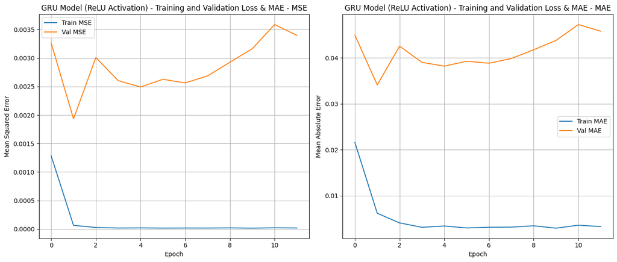

```python
# Plot training history for the ReLU model
plot_training_history(history_gru_relu, "GRU Model (ReLU Activation) - Training and Validation Loss & MAE")
```

```python
# Generate predictions with ReLU-activated GRU model
start_time = time.time()

relu_predictions = gru_model_relu.predict(X_test_multi)

end_time = time.time()
gru_relu_prediction_time = end_time - start_time

# Create dummy volume column to inverse-transform
dummy_volume_relu = np.zeros_like(relu_predictions)
combined_relu_pred = np.concatenate((relu_predictions, dummy_volume_relu), axis=1)
combined_relu_true = np.concatenate((y_test_multi.reshape(-1, 1), dummy_volume_relu), axis=1)

# Invert scaling
relu_predictions_unscaled = multi_scaler.inverse_transform(combined_relu_pred)[:, 0]
y_test_unscaled_relu = multi_scaler.inverse_transform(combined_relu_true)[:, 0]
```

```
22/22 ━━━━━━━━━━━━━━━━━━━━ 1s 36ms/step
```

```python
# Evaluate ReLU model performance
relu_rmse = np.sqrt(np.mean((relu_predictions_unscaled - y_test_unscaled_relu) ** 2))
relu_mae = np.mean(np.abs(relu_predictions_unscaled - y_test_unscaled_relu))

print(f"GRU (ReLU Activation) RMSE: {relu_rmse:.4f}")
print(f"GRU (ReLU Activation) MAE:  {relu_mae:.4f}")
print(f"GRU (ReLU Activation) Training Time: {gru_relu_training_time:.2f} seconds")
print(f"GRU (ReLU Activation) Prediction Time: {gru_relu_prediction_time:.2f} seconds")
```

```
GRU (ReLU Activation) RMSE: 23.6138
GRU (ReLU Activation) MAE:  22.3483
GRU (ReLU Activation) Training Time: 100.51 seconds
GRU (ReLU Activation) Prediction Time: 1.31 seconds
```

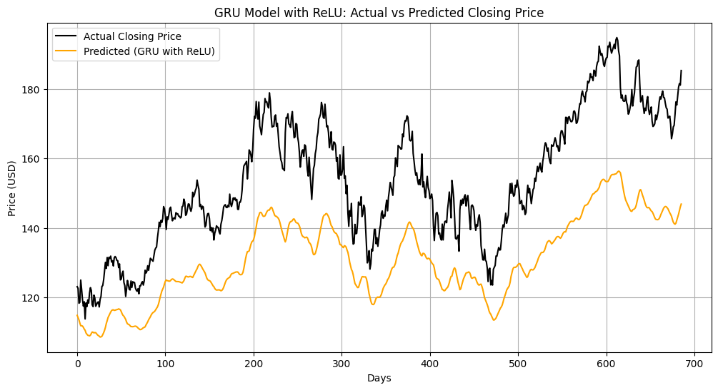

```python
# Plot actual vs predicted values for GRU-ReLU model
plt.figure(figsize=(12, 6))
plt.plot(y_test_unscaled_relu, label='Actual Closing Price', color='black')
plt.plot(relu_predictions_unscaled, label='Predicted (GRU with ReLU)', color='orange')
plt.title('GRU Model with ReLU: Actual vs Predicted Closing Price')
plt.xlabel('Days')
plt.ylabel('Price (USD)')
plt.legend()
plt.grid(True)
plt.show()
```

### **Explanation**

- I set `activation='relu'` in both GRU layers to modify how the candidate hidden state is computed.
- The `recurrent_activation='sigmoid'` remains unchanged, as it governs the gate mechanisms in GRUs.
- I also use `ReLU` in the intermediate dense layer to maintain activation consistency.
- The model is trained with early stopping and evaluated using RMSE and MAE.
- The predictions are inverse-scaled and compared with actual closing prices.

## **4.2 GRU Model with Leaky ReLU Activation**

### **Overview**

This model replaces ReLU with **Leaky ReLU** in the dense layer. Leaky ReLU allows a small gradient for negative inputs, which helps avoid the "dying ReLU" problem where neurons become inactive.

```python
from tensorflow.keras.layers import LeakyReLU

# Define GRU model with Leaky ReLU in the dense layer
gru_model_leakyrelu = Sequential([
    GRU(50, return_sequences=True, input_shape=(seq_length, 2)),
    GRU(50, return_sequences=False),
    Dense(25),
    LeakyReLU(alpha=0.01),  # Apply Leaky ReLU activation here
    Dense(1)
])

# Compile the model
gru_model_leakyrelu.compile(
    optimizer=Adam(learning_rate=0.001),
    loss='mean_squared_error',
    metrics=['mean_absolute_error']
)
```

```
Model: "sequential_4"
```

```
┏━━━━━━━━━━━━━━━━━━━━━━━━━━━━━━━━━┳━━━━━━━━━━━━━━━━━━━━━━━━┳━━━━━━━━━━━━━━━┓
┃ Layer (type)                    ┃ Output Shape           ┃       Param # ┃
┡━━━━━━━━━━━━━━━━━━━━━━━━━━━━━━━━━╇━━━━━━━━━━━━━━━━━━━━━━━━╇━━━━━━━━━━━━━━━┩
│ gru_6 (GRU)                     │ (None, 60, 50)         │         8,100 │
├─────────────────────────────────┼────────────────────────┼───────────────┤
│ gru_7 (GRU)                     │ (None, 50)             │        15,300 │
├─────────────────────────────────┼────────────────────────┼───────────────┤
│ dense_8 (Dense)                 │ (None, 25)             │         1,275 │
├─────────────────────────────────┼────────────────────────┼───────────────┤
│ leaky_re_lu (LeakyReLU)         │ (None, 25)             │             0 │
├─────────────────────────────────┼────────────────────────┼───────────────┤
│ dense_9 (Dense)                 │ (None, 1)              │            26 │
└─────────────────────────────────┴────────────────────────┴───────────────┘
```

```
 Total params: 24,701 (96.49 KB)
```

```
 Trainable params: 24,701 (96.49 KB)
```

```
 Non-trainable params: 0 (0.00 B)
```

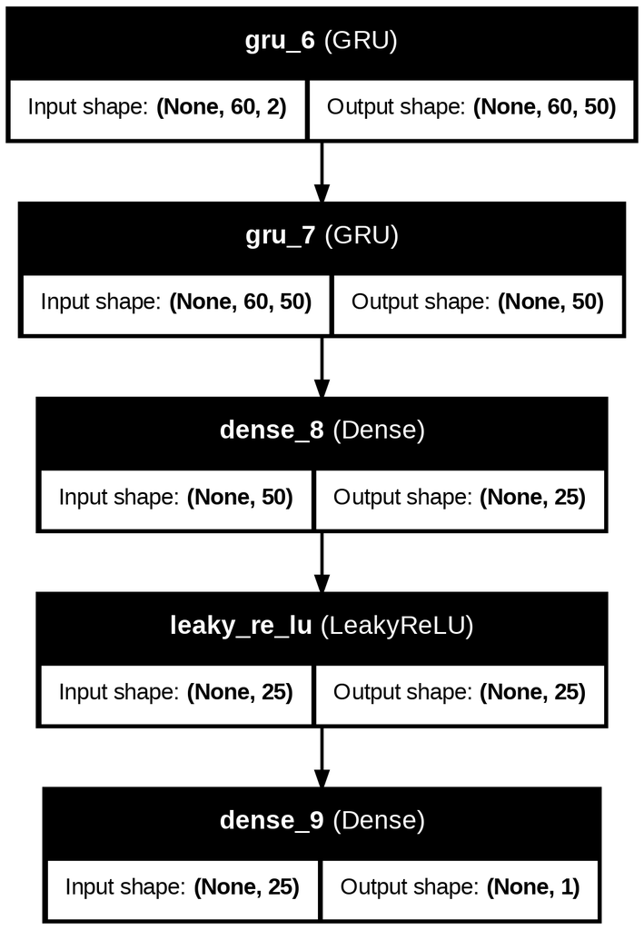

```python
# Summarize model and save architecture
gru_model_leakyrelu.summary()
plot_model(gru_model_leakyrelu, to_file="gru_model_leakyrelu.png", show_shapes=True, show_layer_names=True)
```

```python
# Train the GRU model with Leaky ReLU
start_time = time.time()

history_gru_leakyrelu = gru_model_leakyrelu.fit(
    X_train_multi,
    y_train_multi,
    batch_size=32,
    epochs=100,
    validation_split=0.1,
    callbacks=[early_stop],
    verbose=1
)

end_time = time.time()
gru_leakyrelu_training_time = end_time - start_time
```

```
78/78 ━━━━━━━━━━━━━━━━━━━━ 12s 82ms/step - loss: 0.0017 - mean_absolute_error: 0.0245 - val_loss: 3.8244e-04 - val_mean_absolute_error: 0.0147
78/78 ━━━━━━━━━━━━━━━━━━━━ 10s 81ms/step - loss: 1.7535e-05 - mean_absolute_error: 0.0030 - val_loss: 3.7776e-04 - val_mean_absolute_error: 0.0145
78/78 ━━━━━━━━━━━━━━━━━━━━ 6s 77ms/step - loss: 1.5783e-05 - mean_absolute_error: 0.0029 - val_loss: 3.6229e-04 - val_mean_absolute_error: 0.0142
78/78 ━━━━━━━━━━━━━━━━━━━━ 10s 72ms/step - loss: 1.7769e-05 - mean_absolute_error: 0.0030 - val_loss: 4.2814e-04 - val_mean_absolute_error: 0.0154
78/78 ━━━━━━━━━━━━━━━━━━━━ 10s 73ms/step - loss: 1.5876e-05 - mean_absolute_error: 0.0029 - val_loss: 3.4568e-04 - val_mean_absolute_error: 0.0140
78/78 ━━━━━━━━━━━━━━━━━━━━ 10s 73ms/step - loss: 1.6552e-05 - mean_absolute_error: 0.0029 - val_loss: 5.0612e-04 - val_mean_absolute_error: 0.0171
78/78 ━━━━━━━━━━━━━━━━━━━━ 7s 84ms/step - loss: 1.8978e-05 - mean_absolute_error: 0.0033 - val_loss: 3.2804e-04 - val_mean_absolute_error: 0.0135
78/78 ━━━━━━━━━━━━━━━━━━━━ 9s 75ms/step - loss: 1.5354e-05 - mean_absolute_error: 0.0029 - val_loss: 3.7064e-04 - val_mean_absolute_error: 0.0143
78/78 ━━━━━━━━━━━━━━━━━━━━ 10s 72ms/step - loss: 1.6291e-05 - mean_absolute_error: 0.0030 - val_loss: 3.2491e-04 - val_mean_absolute_error: 0.0133
78/78 ━━━━━━━━━━━━━━━━━━━━ 10s 74ms/step - loss: 1.3686e-05 - mean_absolute_error: 0.0027 - val_loss: 3.5505e-04 - val_mean_absolute_error: 0.0140
78/78 ━━━━━━━━━━━━━━━━━━━━ 10s 73ms/step - loss: 1.3968e-05 - mean_absolute_error: 0.0027 - val_loss: 3.2547e-04 - val_mean_absolute_error: 0.0133
78/78 ━━━━━━━━━━━━━━━━━━━━ 7s 83ms/step - loss: 1.2756e-05 - mean_absolute_error: 0.0026 - val_loss: 3.7744e-04 - val_mean_absolute_error: 0.0154
78/78 ━━━━━━━━━━━━━━━━━━━━ 9s 73ms/step - loss: 2.5295e-05 - mean_absolute_error: 0.0040 - val_loss: 2.7897e-04 - val_mean_absolute_error: 0.0123
78/78 ━━━━━━━━━━━━━━━━━━━━ 10s 73ms/step - loss: 1.6002e-05 - mean_absolute_error: 0.0030 - val_loss: 3.6371e-04 - val_mean_absolute_error: 0.0151
78/78 ━━━━━━━━━━━━━━━━━━━━ 10s 74ms/step - loss: 1.9231e-05 - mean_absolute_error: 0.0032 - val_loss: 2.7121e-04 - val_mean_absolute_error: 0.0122
78/78 ━━━━━━━━━━━━━━━━━━━━ 10s 75ms/step - loss: 1.2075e-05 - mean_absolute_error: 0.0025 - val_loss: 3.0570e-04 - val_mean_absolute_error: 0.0131
78/78 ━━━━━━━━━━━━━━━━━━━━ 6s 81ms/step - loss: 1.4379e-05 - mean_absolute_error: 0.0029 - val_loss: 3.3662e-04 - val_mean_absolute_error: 0.0141
78/78 ━━━━━━━━━━━━━━━━━━━━ 6s 74ms/step - loss: 1.4196e-05 - mean_absolute_error: 0.0028 - val_loss: 2.4775e-04 - val_mean_absolute_error: 0.0116
78/78 ━━━━━━━━━━━━━━━━━━━━ 11s 84ms/step - loss: 1.3665e-05 - mean_absolute_error: 0.0028 - val_loss: 2.4696e-04 - val_mean_absolute_error: 0.0115
78/78 ━━━━━━━━━━━━━━━━━━━━ 6s 71ms/step - loss: 1.1565e-05 - mean_absolute_error: 0.0026 - val_loss: 2.9221e-04 - val_mean_absolute_error: 0.0126
78/78 ━━━━━━━━━━━━━━━━━━━━ 7s 86ms/step - loss: 1.8475e-05 - mean_absolute_error: 0.0033 - val_loss: 2.5085e-04 - val_mean_absolute_error: 0.0116
78/78 ━━━━━━━━━━━━━━━━━━━━ 6s 71ms/step - loss: 1.1159e-05 - mean_absolute_error: 0.0024 - val_loss: 2.6283e-04 - val_mean_absolute_error: 0.0122
78/78 ━━━━━━━━━━━━━━━━━━━━ 7s 86ms/step - loss: 1.4460e-05 - mean_absolute_error: 0.0029 - val_loss: 3.0366e-04 - val_mean_absolute_error: 0.0130
78/78 ━━━━━━━━━━━━━━━━━━━━ 6s 75ms/step - loss: 1.4738e-05 - mean_absolute_error: 0.0029 - val_loss: 3.9277e-04 - val_mean_absolute_error: 0.0150
78/78 ━━━━━━━━━━━━━━━━━━━━ 7s 84ms/step - loss: 1.1261e-05 - mean_absolute_error: 0.0025 - val_loss: 4.5955e-04 - val_mean_absolute_error: 0.0164
78/78 ━━━━━━━━━━━━━━━━━━━━ 11s 92ms/step - loss: 1.0333e-05 - mean_absolute_error: 0.0023 - val_loss: 5.2372e-04 - val_mean_absolute_error: 0.0176
78/78 ━━━━━━━━━━━━━━━━━━━━ 9s 76ms/step - loss: 1.1338e-05 - mean_absolute_error: 0.0025 - val_loss: 3.3729e-04 - val_mean_absolute_error: 0.0139
78/78 ━━━━━━━━━━━━━━━━━━━━ 10s 73ms/step - loss: 1.2471e-05 - mean_absolute_error: 0.0027 - val_loss: 4.4830e-04 - val_mean_absolute_error: 0.0163
78/78 ━━━━━━━━━━━━━━━━━━━━ 7s 84ms/step - loss: 1.0757e-05 - mean_absolute_error: 0.0023 - val_loss: 3.5661e-04 - val_mean_absolute_error: 0.0143
Epoch 29: early stopping
Restoring model weights from the end of the best epoch: 19.
```

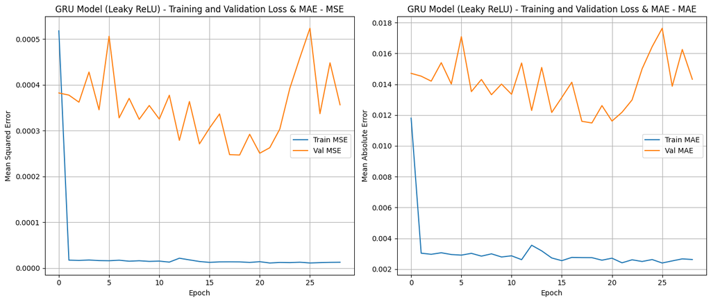

```python
# Plot training history for Leaky ReLU model
plot_training_history(history_gru_leakyrelu, "GRU Model (Leaky ReLU) - Training and Validation Loss & MAE")
```

```python
# Predict with Leaky ReLU model
start_time = time.time()

leakyrelu_predictions = gru_model_leakyrelu.predict(X_test_multi)

end_time = time.time()
gru_leakyrelu_prediction_time = end_time - start_time

# Invert scale
dummy_volume_leaky = np.zeros_like(leakyrelu_predictions)
combined_pred_leaky = np.concatenate((leakyrelu_predictions, dummy_volume_leaky), axis=1)
combined_true_leaky = np.concatenate((y_test_multi.reshape(-1, 1), dummy_volume_leaky), axis=1)

leaky_predictions_unscaled = multi_scaler.inverse_transform(combined_pred_leaky)[:, 0]
y_test_unscaled_leaky = multi_scaler.inverse_transform(combined_true_leaky)[:, 0]

# RMSE and MAE
leaky_rmse = np.sqrt(np.mean((leaky_predictions_unscaled - y_test_unscaled_leaky) ** 2))
leaky_mae = np.mean(np.abs(leaky_predictions_unscaled - y_test_unscaled_leaky))

print(f"GRU (Leaky ReLU) RMSE: {leaky_rmse:.4f}")
print(f"GRU (Leaky ReLU) MAE:  {leaky_mae:.4f}")
print(f"GRU (Leaky ReLU) Training Time: {gru_leakyrelu_training_time:.2f} seconds")
print(f"GRU (Leaky ReLU) Prediction Time: {gru_leakyrelu_prediction_time:.2f} seconds")
```

```
22/22 ━━━━━━━━━━━━━━━━━━━━ 1s 35ms/step
GRU (Leaky ReLU) RMSE: 4.6519
GRU (Leaky ReLU) MAE:  3.7823
GRU (Leaky ReLU) Training Time: 252.28 seconds
GRU (Leaky ReLU) Prediction Time: 1.34 seconds
```

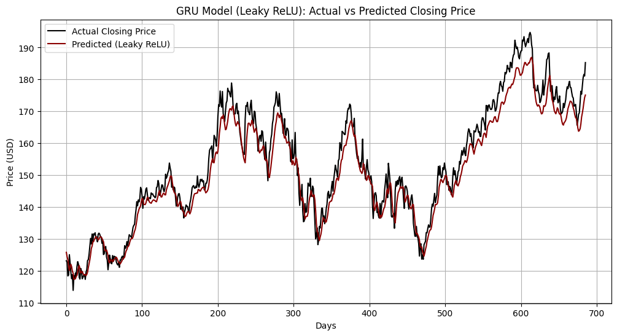

```python
# Plot actual vs predicted for Leaky ReLU
plt.figure(figsize=(12, 6))
plt.plot(y_test_unscaled_leaky, label='Actual Closing Price', color='black')
plt.plot(leaky_predictions_unscaled, label='Predicted (Leaky ReLU)', color='darkred')
plt.title('GRU Model (Leaky ReLU): Actual vs Predicted Closing Price')
plt.xlabel('Days')
plt.ylabel('Price (USD)')
plt.legend()
plt.grid(True)
plt.show()
```

### **Explanation**

- The GRU layers use default `tanh` activation.
- Leaky ReLU is applied only in the intermediate `Dense(25)` layer.
- The model is trained with early stopping and evaluated using RMSE and MAE.
- The predictions are inverse-scaled and compared with actual closing prices.

### **Results**

- An **RMSE of 4.6519** indicates moderate degradation in performance compared to the baseline GRU models, with more frequent deviations from actual prices, especially during volatile phases.
- An **MAE of 3.7823** shows that the model’s average daily error exceeds $3.70, which is significantly higher than the top-performing models and would likely be unacceptable in financial applications requiring precision.
- **Training Time:** 252.28 seconds — faster than most variants, making this model relatively efficient in terms of training cost.
- **Prediction Time:** 1.34 seconds — reasonably fast and deployment-friendly from an inference perspective.
- The prediction plot shows that while **Leaky ReLU helps retain some responsiveness to price movement**, the model still **tends to underpredict during price surges** and smooth out key turning points. This suggests that although it performs better than ReLU, **Leaky ReLU still lacks the expressive capability needed for high-accuracy forecasting in this setting**.

## **4.3 GRU Model with ELU Activation**

### **Overview**

This model uses **ELU (Exponential Linear Unit)** as the activation function in both GRU and dense layers. ELU is a smooth, non-linear function that enables better learning dynamics for negative values compared to ReLU.

```python
from tensorflow.keras.layers import ELU

# Define GRU model with ELU activation in the dense layer
gru_model_elu = Sequential([
    GRU(50, return_sequences=True, input_shape=(seq_length, 2),
         activation='elu', recurrent_activation='sigmoid'),
    GRU(50, return_sequences=False,
         activation='elu', recurrent_activation='sigmoid'),
    Dense(25, activation='elu'),
    Dense(1)
])

# Compile the model
gru_model_elu.compile(
    optimizer=Adam(learning_rate=0.001),
    loss='mean_squared_error',
    metrics=['mean_absolute_error']
)
```

```
Model: "sequential_5"
```

```
┏━━━━━━━━━━━━━━━━━━━━━━━━━━━━━━━━━┳━━━━━━━━━━━━━━━━━━━━━━━━┳━━━━━━━━━━━━━━━┓
┃ Layer (type)                    ┃ Output Shape           ┃       Param # ┃
┡━━━━━━━━━━━━━━━━━━━━━━━━━━━━━━━━━╇━━━━━━━━━━━━━━━━━━━━━━━━╇━━━━━━━━━━━━━━━┩
│ gru_8 (GRU)                     │ (None, 60, 50)         │         8,100 │
├─────────────────────────────────┼────────────────────────┼───────────────┤
│ gru_9 (GRU)                     │ (None, 50)             │        15,300 │
├─────────────────────────────────┼────────────────────────┼───────────────┤
│ dense_10 (Dense)                │ (None, 25)             │         1,275 │
├─────────────────────────────────┼────────────────────────┼───────────────┤
│ dense_11 (Dense)                │ (None, 1)              │            26 │
└─────────────────────────────────┴────────────────────────┴───────────────┘
```

```
 Total params: 24,701 (96.49 KB)
```

```
 Trainable params: 24,701 (96.49 KB)
```

```
 Non-trainable params: 0 (0.00 B)
```

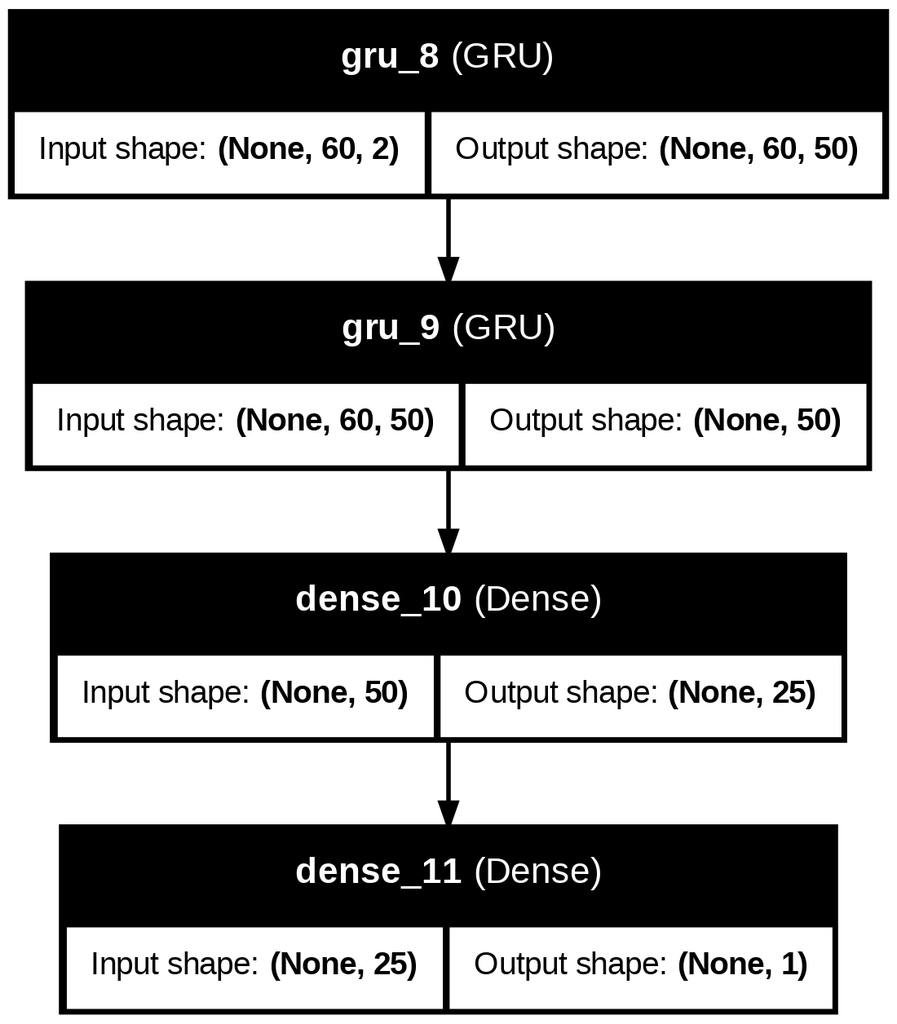

```python
# Summarize model and save diagram
gru_model_elu.summary()
plot_model(gru_model_elu, to_file="gru_model_elu.png", show_shapes=True, show_layer_names=True)
```

```python
# Train the GRU model with ELU activation
start_time = time.time()

history_gru_elu = gru_model_elu.fit(
    X_train_multi,
    y_train_multi,
    batch_size=32,
    epochs=100,
    validation_split=0.1,
    callbacks=[early_stop],
    verbose=1
)

end_time = time.time()
gru_elu_training_time = end_time - start_time
```

```
78/78 ━━━━━━━━━━━━━━━━━━━━ 12s 82ms/step - loss: 0.0022 - mean_absolute_error: 0.0329 - val_loss: 0.0010 - val_mean_absolute_error: 0.0260
78/78 ━━━━━━━━━━━━━━━━━━━━ 10s 84ms/step - loss: 1.9124e-05 - mean_absolute_error: 0.0032 - val_loss: 0.0011 - val_mean_absolute_error: 0.0274
78/78 ━━━━━━━━━━━━━━━━━━━━ 10s 84ms/step - loss: 1.8339e-05 - mean_absolute_error: 0.0030 - val_loss: 9.6985e-04 - val_mean_absolute_error: 0.0251
78/78 ━━━━━━━━━━━━━━━━━━━━ 6s 72ms/step - loss: 1.8219e-05 - mean_absolute_error: 0.0030 - val_loss: 0.0011 - val_mean_absolute_error: 0.0269
78/78 ━━━━━━━━━━━━━━━━━━━━ 7s 84ms/step - loss: 1.8916e-05 - mean_absolute_error: 0.0031 - val_loss: 0.0011 - val_mean_absolute_error: 0.0273
78/78 ━━━━━━━━━━━━━━━━━━━━ 6s 71ms/step - loss: 1.5724e-05 - mean_absolute_error: 0.0028 - val_loss: 6.1811e-04 - val_mean_absolute_error: 0.0193
78/78 ━━━━━━━━━━━━━━━━━━━━ 7s 84ms/step - loss: 1.7012e-05 - mean_absolute_error: 0.0030 - val_loss: 5.3727e-04 - val_mean_absolute_error: 0.0177
78/78 ━━━━━━━━━━━━━━━━━━━━ 9s 73ms/step - loss: 1.5897e-05 - mean_absolute_error: 0.0029 - val_loss: 6.5645e-04 - val_mean_absolute_error: 0.0206
78/78 ━━━━━━━━━━━━━━━━━━━━ 7s 83ms/step - loss: 1.5951e-05 - mean_absolute_error: 0.0029 - val_loss: 7.1824e-04 - val_mean_absolute_error: 0.0217
78/78 ━━━━━━━━━━━━━━━━━━━━ 10s 84ms/step - loss: 1.5241e-05 - mean_absolute_error: 0.0028 - val_loss: 7.6736e-04 - val_mean_absolute_error: 0.0227
78/78 ━━━━━━━━━━━━━━━━━━━━ 10s 77ms/step - loss: 1.2655e-05 - mean_absolute_error: 0.0026 - val_loss: 4.9936e-04 - val_mean_absolute_error: 0.0174
78/78 ━━━━━━━━━━━━━━━━━━━━ 11s 87ms/step - loss: 1.4436e-05 - mean_absolute_error: 0.0028 - val_loss: 6.6673e-04 - val_mean_absolute_error: 0.0211
78/78 ━━━━━━━━━━━━━━━━━━━━ 9s 71ms/step - loss: 1.5431e-05 - mean_absolute_error: 0.0029 - val_loss: 6.2432e-04 - val_mean_absolute_error: 0.0202
78/78 ━━━━━━━━━━━━━━━━━━━━ 10s 70ms/step - loss: 1.3567e-05 - mean_absolute_error: 0.0026 - val_loss: 4.8098e-04 - val_mean_absolute_error: 0.0172
78/78 ━━━━━━━━━━━━━━━━━━━━ 7s 84ms/step - loss: 1.3922e-05 - mean_absolute_error: 0.0028 - val_loss: 3.4694e-04 - val_mean_absolute_error: 0.0141
78/78 ━━━━━━━━━━━━━━━━━━━━ 9s 72ms/step - loss: 1.1327e-05 - mean_absolute_error: 0.0024 - val_loss: 2.8317e-04 - val_mean_absolute_error: 0.0123
78/78 ━━━━━━━━━━━━━━━━━━━━ 10s 74ms/step - loss: 1.4055e-05 - mean_absolute_error: 0.0027 - val_loss: 3.1390e-04 - val_mean_absolute_error: 0.0133
78/78 ━━━━━━━━━━━━━━━━━━━━ 10s 73ms/step - loss: 2.0531e-05 - mean_absolute_error: 0.0035 - val_loss: 2.7964e-04 - val_mean_absolute_error: 0.0123
78/78 ━━━━━━━━━━━━━━━━━━━━ 7s 84ms/step - loss: 1.2392e-05 - mean_absolute_error: 0.0025 - val_loss: 2.6915e-04 - val_mean_absolute_error: 0.0119
78/78 ━━━━━━━━━━━━━━━━━━━━ 10s 75ms/step - loss: 1.6115e-05 - mean_absolute_error: 0.0030 - val_loss: 3.4720e-04 - val_mean_absolute_error: 0.0145
78/78 ━━━━━━━━━━━━━━━━━━━━ 10s 71ms/step - loss: 1.1854e-05 - mean_absolute_error: 0.0025 - val_loss: 2.6913e-04 - val_mean_absolute_error: 0.0121
78/78 ━━━━━━━━━━━━━━━━━━━━ 10s 72ms/step - loss: 8.3331e-06 - mean_absolute_error: 0.0021 - val_loss: 2.3393e-04 - val_mean_absolute_error: 0.0111
78/78 ━━━━━━━━━━━━━━━━━━━━ 10s 74ms/step - loss: 1.1984e-05 - mean_absolute_error: 0.0026 - val_loss: 4.3509e-04 - val_mean_absolute_error: 0.0168
78/78 ━━━━━━━━━━━━━━━━━━━━ 10s 74ms/step - loss: 1.2620e-05 - mean_absolute_error: 0.0027 - val_loss: 4.0084e-04 - val_mean_absolute_error: 0.0163
78/78 ━━━━━━━━━━━━━━━━━━━━ 6s 78ms/step - loss: 2.8172e-05 - mean_absolute_error: 0.0043 - val_loss: 2.3109e-04 - val_mean_absolute_error: 0.0110
78/78 ━━━━━━━━━━━━━━━━━━━━ 10s 78ms/step - loss: 1.6695e-05 - mean_absolute_error: 0.0032 - val_loss: 2.3547e-04 - val_mean_absolute_error: 0.0112
78/78 ━━━━━━━━━━━━━━━━━━━━ 7s 88ms/step - loss: 9.1983e-06 - mean_absolute_error: 0.0022 - val_loss: 2.2472e-04 - val_mean_absolute_error: 0.0108
78/78 ━━━━━━━━━━━━━━━━━━━━ 6s 73ms/step - loss: 9.9983e-06 - mean_absolute_error: 0.0023 - val_loss: 3.3554e-04 - val_mean_absolute_error: 0.0146
78/78 ━━━━━━━━━━━━━━━━━━━━ 10s 73ms/step - loss: 1.1377e-05 - mean_absolute_error: 0.0025 - val_loss: 4.4808e-04 - val_mean_absolute_error: 0.0175
78/78 ━━━━━━━━━━━━━━━━━━━━ 10s 71ms/step - loss: 3.1409e-05 - mean_absolute_error: 0.0045 - val_loss: 2.2259e-04 - val_mean_absolute_error: 0.0109
78/78 ━━━━━━━━━━━━━━━━━━━━ 10s 73ms/step - loss: 1.3656e-05 - mean_absolute_error: 0.0027 - val_loss: 2.6695e-04 - val_mean_absolute_error: 0.0124
78/78 ━━━━━━━━━━━━━━━━━━━━ 6s 79ms/step - loss: 1.2531e-05 - mean_absolute_error: 0.0027 - val_loss: 2.5221e-04 - val_mean_absolute_error: 0.0121
78/78 ━━━━━━━━━━━━━━━━━━━━ 10s 73ms/step - loss: 1.4232e-05 - mean_absolute_error: 0.0028 - val_loss: 2.6715e-04 - val_mean_absolute_error: 0.0127
78/78 ━━━━━━━━━━━━━━━━━━━━ 10s 74ms/step - loss: 1.7710e-05 - mean_absolute_error: 0.0032 - val_loss: 2.4750e-04 - val_mean_absolute_error: 0.0117
78/78 ━━━━━━━━━━━━━━━━━━━━ 10s 74ms/step - loss: 1.2690e-05 - mean_absolute_error: 0.0027 - val_loss: 2.8305e-04 - val_mean_absolute_error: 0.0128
78/78 ━━━━━━━━━━━━━━━━━━━━ 10s 73ms/step - loss: 8.6606e-06 - mean_absolute_error: 0.0021 - val_loss: 1.9751e-04 - val_mean_absolute_error: 0.0101
78/78 ━━━━━━━━━━━━━━━━━━━━ 6s 79ms/step - loss: 8.8916e-06 - mean_absolute_error: 0.0021 - val_loss: 1.9579e-04 - val_mean_absolute_error: 0.0101
78/78 ━━━━━━━━━━━━━━━━━━━━ 10s 74ms/step - loss: 1.0131e-05 - mean_absolute_error: 0.0024 - val_loss: 1.9686e-04 - val_mean_absolute_error: 0.0102
78/78 ━━━━━━━━━━━━━━━━━━━━ 10s 72ms/step - loss: 1.1154e-05 - mean_absolute_error: 0.0024 - val_loss: 2.0630e-04 - val_mean_absolute_error: 0.0105
78/78 ━━━━━━━━━━━━━━━━━━━━ 10s 72ms/step - loss: 8.2669e-06 - mean_absolute_error: 0.0019 - val_loss: 1.9546e-04 - val_mean_absolute_error: 0.0102
```

[output cut: 20 more lines]

```
78/78 ━━━━━━━━━━━━━━━━━━━━ 6s 76ms/step - loss: 9.6385e-06 - mean_absolute_error: 0.0022 - val_loss: 3.2160e-04 - val_mean_absolute_error: 0.0141
78/78 ━━━━━━━━━━━━━━━━━━━━ 6s 80ms/step - loss: 1.3233e-05 - mean_absolute_error: 0.0028 - val_loss: 3.4339e-04 - val_mean_absolute_error: 0.0146
78/78 ━━━━━━━━━━━━━━━━━━━━ 6s 76ms/step - loss: 8.6380e-06 - mean_absolute_error: 0.0020 - val_loss: 1.8402e-04 - val_mean_absolute_error: 0.0099
78/78 ━━━━━━━━━━━━━━━━━━━━ 11s 86ms/step - loss: 7.0537e-06 - mean_absolute_error: 0.0019 - val_loss: 1.8495e-04 - val_mean_absolute_error: 0.0099
78/78 ━━━━━━━━━━━━━━━━━━━━ 10s 85ms/step - loss: 7.8942e-06 - mean_absolute_error: 0.0021 - val_loss: 2.4968e-04 - val_mean_absolute_error: 0.0124
78/78 ━━━━━━━━━━━━━━━━━━━━ 6s 75ms/step - loss: 1.4656e-05 - mean_absolute_error: 0.0029 - val_loss: 1.8939e-04 - val_mean_absolute_error: 0.0100
78/78 ━━━━━━━━━━━━━━━━━━━━ 7s 85ms/step - loss: 6.8785e-06 - mean_absolute_error: 0.0019 - val_loss: 1.8641e-04 - val_mean_absolute_error: 0.0100
78/78 ━━━━━━━━━━━━━━━━━━━━ 9s 75ms/step - loss: 7.5008e-06 - mean_absolute_error: 0.0019 - val_loss: 2.3896e-04 - val_mean_absolute_error: 0.0120
78/78 ━━━━━━━━━━━━━━━━━━━━ 10s 71ms/step - loss: 9.3658e-06 - mean_absolute_error: 0.0022 - val_loss: 2.0382e-04 - val_mean_absolute_error: 0.0106
78/78 ━━━━━━━━━━━━━━━━━━━━ 10s 75ms/step - loss: 1.2035e-05 - mean_absolute_error: 0.0026 - val_loss: 1.9553e-04 - val_mean_absolute_error: 0.0103
78/78 ━━━━━━━━━━━━━━━━━━━━ 10s 72ms/step - loss: 1.0281e-05 - mean_absolute_error: 0.0023 - val_loss: 2.3091e-04 - val_mean_absolute_error: 0.0114
78/78 ━━━━━━━━━━━━━━━━━━━━ 11s 79ms/step - loss: 8.2288e-06 - mean_absolute_error: 0.0021 - val_loss: 3.3505e-04 - val_mean_absolute_error: 0.0145
78/78 ━━━━━━━━━━━━━━━━━━━━ 11s 85ms/step - loss: 1.3104e-05 - mean_absolute_error: 0.0027 - val_loss: 2.8378e-04 - val_mean_absolute_error: 0.0131
Epoch 73: early stopping
Restoring model weights from the end of the best epoch: 63.
```

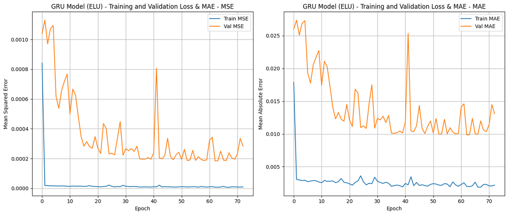

```python
# Plot training history for ELU model
plot_training_history(history_gru_elu, "GRU Model (ELU) - Training and Validation Loss & MAE")
```

```python
# Predict using the ELU model
start_time = time.time()

elu_predictions = gru_model_elu.predict(X_test_multi)

end_time = time.time()
gru_elu_prediction_time = end_time - start_time

# Invert scaling
dummy_volume_elu = np.zeros_like(elu_predictions)
combined_pred_elu = np.concatenate((elu_predictions, dummy_volume_elu), axis=1)
combined_true_elu = np.concatenate((y_test_multi.reshape(-1, 1), dummy_volume_elu), axis=1)

elu_predictions_unscaled = multi_scaler.inverse_transform(combined_pred_elu)[:, 0]
y_test_unscaled_elu = multi_scaler.inverse_transform(combined_true_elu)[:, 0]

# Calculate RMSE and MAE
elu_rmse = np.sqrt(np.mean((elu_predictions_unscaled - y_test_unscaled_elu) ** 2))
elu_mae = np.mean(np.abs(elu_predictions_unscaled - y_test_unscaled_elu))

print(f"GRU (ELU Activation) RMSE: {elu_rmse:.4f}")
print(f"GRU (ELU Activation) MAE:  {elu_mae:.4f}")
print(f"GRU (ELU Activation) Training Time: {gru_elu_training_time:.2f} seconds")
print(f"GRU (ELU Activation) Prediction Time: {gru_elu_prediction_time:.2f} seconds")
```

```
22/22 ━━━━━━━━━━━━━━━━━━━━ 1s 35ms/step
GRU (ELU Activation) RMSE: 2.6807
GRU (ELU Activation) MAE:  2.0306
GRU (ELU Activation) Training Time: 652.66 seconds
GRU (ELU Activation) Prediction Time: 1.34 seconds
```

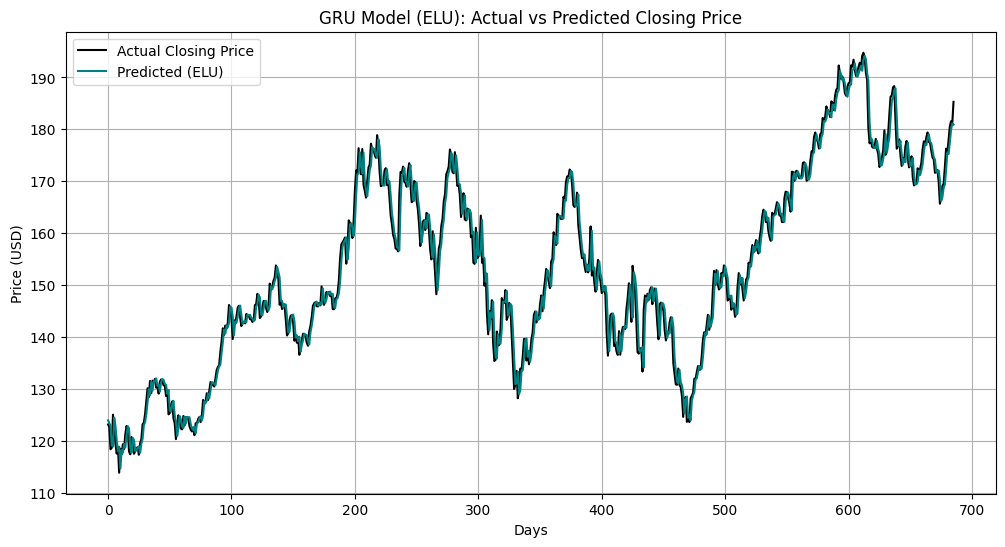

```python
# Plot actual vs predicted closing prices (ELU)
plt.figure(figsize=(12, 6))
plt.plot(y_test_unscaled_elu, label='Actual Closing Price', color='black')
plt.plot(elu_predictions_unscaled, label='Predicted (ELU)', color='teal')
plt.title('GRU Model (ELU): Actual vs Predicted Closing Price')
plt.xlabel('Days')
plt.ylabel('Price (USD)')
plt.legend()
plt.grid(True)
plt.show()
```

### **Explanation**

- The GRU layers use `activation='elu'`, which improves learning for inputs that are slightly negative.
- The intermediate dense layer also uses ELU to maintain smooth gradients throughout the network.
- The model is compiled and trained with the same configuration as prior models.
- Evaluation includes both RMSE and MAE, followed by a visual comparison of predicted vs. actual prices.

## **4.4 GRU Model with SELU Activation**

### **Overview**

This model uses **SELU (Scaled Exponential Linear Unit)**, which introduces self-normalizing properties in neural networks. SELU helps preserve the mean and variance of activations throughout layers, potentially improving training stability and convergence speed.

```python
from tensorflow.keras.initializers import lecun_normal

# Define GRU model with SELU activation in both GRU and dense layers
gru_model_selu = Sequential([
    GRU(50, return_sequences=True, input_shape=(seq_length, 2),
         activation='selu', recurrent_activation='sigmoid', kernel_initializer=lecun_normal()),
    GRU(50, return_sequences=False,
         activation='selu', recurrent_activation='sigmoid', kernel_initializer=lecun_normal()),
    Dense(25, activation='selu', kernel_initializer=lecun_normal()),
    Dense(1)
])

# Compile the model
gru_model_selu.compile(
    optimizer=Adam(learning_rate=0.001),
    loss='mean_squared_error',
    metrics=['mean_absolute_error']
)
```

```
Model: "sequential_6"
```

```
┏━━━━━━━━━━━━━━━━━━━━━━━━━━━━━━━━━┳━━━━━━━━━━━━━━━━━━━━━━━━┳━━━━━━━━━━━━━━━┓
┃ Layer (type)                    ┃ Output Shape           ┃       Param # ┃
┡━━━━━━━━━━━━━━━━━━━━━━━━━━━━━━━━━╇━━━━━━━━━━━━━━━━━━━━━━━━╇━━━━━━━━━━━━━━━┩
│ gru_10 (GRU)                    │ (None, 60, 50)         │         8,100 │
├─────────────────────────────────┼────────────────────────┼───────────────┤
│ gru_11 (GRU)                    │ (None, 50)             │        15,300 │
├─────────────────────────────────┼────────────────────────┼───────────────┤
│ dense_12 (Dense)                │ (None, 25)             │         1,275 │
├─────────────────────────────────┼────────────────────────┼───────────────┤
│ dense_13 (Dense)                │ (None, 1)              │            26 │
└─────────────────────────────────┴────────────────────────┴───────────────┘
```

```
 Total params: 24,701 (96.49 KB)
```

```
 Trainable params: 24,701 (96.49 KB)
```

```
 Non-trainable params: 0 (0.00 B)
```

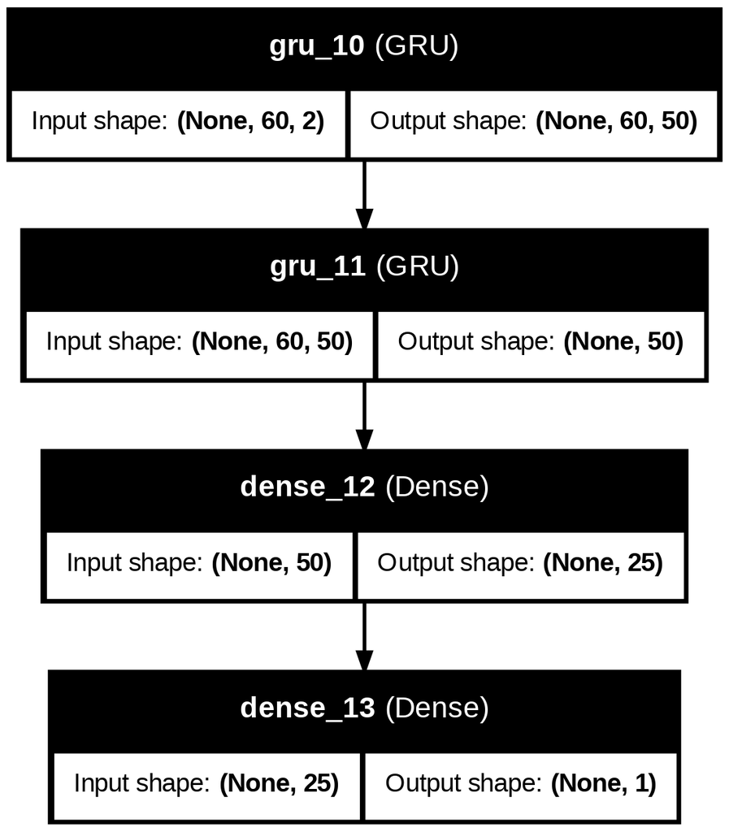

```python
# Summarize and save SELU model
gru_model_selu.summary()
plot_model(gru_model_selu, to_file="gru_model_selu.png", show_shapes=True, show_layer_names=True)
```

```python
# Train the SELU-activated GRU model
start_time = time.time()

history_gru_selu = gru_model_selu.fit(
    X_train_multi,
    y_train_multi,
    batch_size=32,
    epochs=100,
    validation_split=0.1,
    callbacks=[early_stop],
    verbose=1
)

end_time = time.time()
gru_selu_training_time = end_time - start_time
```

```
78/78 ━━━━━━━━━━━━━━━━━━━━ 12s 81ms/step - loss: 0.0103 - mean_absolute_error: 0.0719 - val_loss: 0.0010 - val_mean_absolute_error: 0.0268
78/78 ━━━━━━━━━━━━━━━━━━━━ 10s 74ms/step - loss: 5.5526e-05 - mean_absolute_error: 0.0059 - val_loss: 5.0705e-04 - val_mean_absolute_error: 0.0181
78/78 ━━━━━━━━━━━━━━━━━━━━ 10s 77ms/step - loss: 2.3729e-05 - mean_absolute_error: 0.0037 - val_loss: 3.2233e-04 - val_mean_absolute_error: 0.0136
78/78 ━━━━━━━━━━━━━━━━━━━━ 6s 76ms/step - loss: 2.0865e-05 - mean_absolute_error: 0.0033 - val_loss: 3.0007e-04 - val_mean_absolute_error: 0.0129
78/78 ━━━━━━━━━━━━━━━━━━━━ 6s 79ms/step - loss: 2.9234e-05 - mean_absolute_error: 0.0042 - val_loss: 3.5704e-04 - val_mean_absolute_error: 0.0140
78/78 ━━━━━━━━━━━━━━━━━━━━ 11s 85ms/step - loss: 2.0220e-05 - mean_absolute_error: 0.0035 - val_loss: 3.1098e-04 - val_mean_absolute_error: 0.0136
78/78 ━━━━━━━━━━━━━━━━━━━━ 6s 71ms/step - loss: 2.0149e-05 - mean_absolute_error: 0.0035 - val_loss: 3.0376e-04 - val_mean_absolute_error: 0.0131
78/78 ━━━━━━━━━━━━━━━━━━━━ 7s 83ms/step - loss: 1.5723e-05 - mean_absolute_error: 0.0030 - val_loss: 3.6294e-04 - val_mean_absolute_error: 0.0140
78/78 ━━━━━━━━━━━━━━━━━━━━ 6s 71ms/step - loss: 2.0562e-05 - mean_absolute_error: 0.0034 - val_loss: 3.1434e-04 - val_mean_absolute_error: 0.0134
78/78 ━━━━━━━━━━━━━━━━━━━━ 10s 71ms/step - loss: 1.2852e-05 - mean_absolute_error: 0.0027 - val_loss: 3.5588e-04 - val_mean_absolute_error: 0.0150
78/78 ━━━━━━━━━━━━━━━━━━━━ 11s 74ms/step - loss: 3.5091e-05 - mean_absolute_error: 0.0046 - val_loss: 3.2911e-04 - val_mean_absolute_error: 0.0134
78/78 ━━━━━━━━━━━━━━━━━━━━ 6s 79ms/step - loss: 1.5089e-05 - mean_absolute_error: 0.0029 - val_loss: 5.0744e-04 - val_mean_absolute_error: 0.0166
78/78 ━━━━━━━━━━━━━━━━━━━━ 6s 75ms/step - loss: 4.0465e-05 - mean_absolute_error: 0.0049 - val_loss: 3.3488e-04 - val_mean_absolute_error: 0.0141
78/78 ━━━━━━━━━━━━━━━━━━━━ 11s 85ms/step - loss: 2.3176e-05 - mean_absolute_error: 0.0036 - val_loss: 3.7899e-04 - val_mean_absolute_error: 0.0144
Epoch 14: early stopping
Restoring model weights from the end of the best epoch: 4.
```

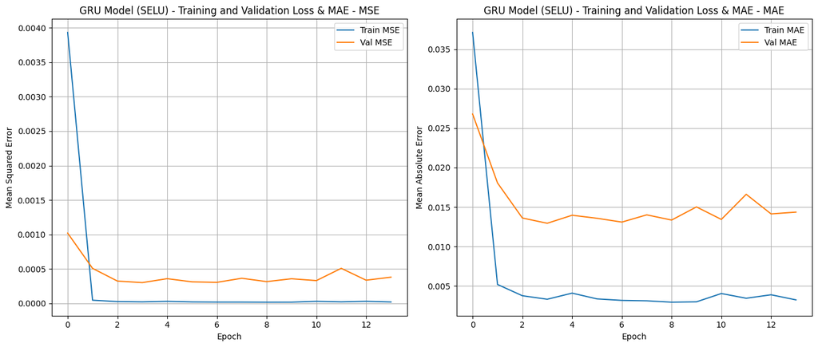

```python
# Plot training history for SELU model
plot_training_history(history_gru_selu, "GRU Model (SELU) - Training and Validation Loss & MAE")
```

```python
# Predict using SELU model
start_time = time.time()

selu_predictions = gru_model_selu.predict(X_test_multi)

end_time = time.time()
gru_selu_prediction_time = end_time - start_time

# Invert scaling
dummy_volume_selu = np.zeros_like(selu_predictions)
combined_pred_selu = np.concatenate((selu_predictions, dummy_volume_selu), axis=1)
combined_true_selu = np.concatenate((y_test_multi.reshape(-1, 1), dummy_volume_selu), axis=1)

selu_predictions_unscaled = multi_scaler.inverse_transform(combined_pred_selu)[:, 0]
y_test_unscaled_selu = multi_scaler.inverse_transform(combined_true_selu)[:, 0]

# RMSE and MAE
selu_rmse = np.sqrt(np.mean((selu_predictions_unscaled - y_test_unscaled_selu) ** 2))
selu_mae = np.mean(np.abs(selu_predictions_unscaled - y_test_unscaled_selu))

print(f"GRU (SELU Activation) RMSE: {selu_rmse:.4f}")
print(f"GRU (SELU Activation) MAE:  {selu_mae:.4f}")
print(f"GRU (SELU Activation) Training Time: {gru_selu_training_time:.2f} seconds")
print(f"GRU (SELU Activation) Prediction Time: {gru_selu_prediction_time:.2f} seconds")
```

```
22/22 ━━━━━━━━━━━━━━━━━━━━ 1s 34ms/step
GRU (SELU Activation) RMSE: 6.1483
GRU (SELU Activation) MAE:  5.2718
GRU (SELU Activation) Training Time: 116.56 seconds
GRU (SELU Activation) Prediction Time: 1.20 seconds
```

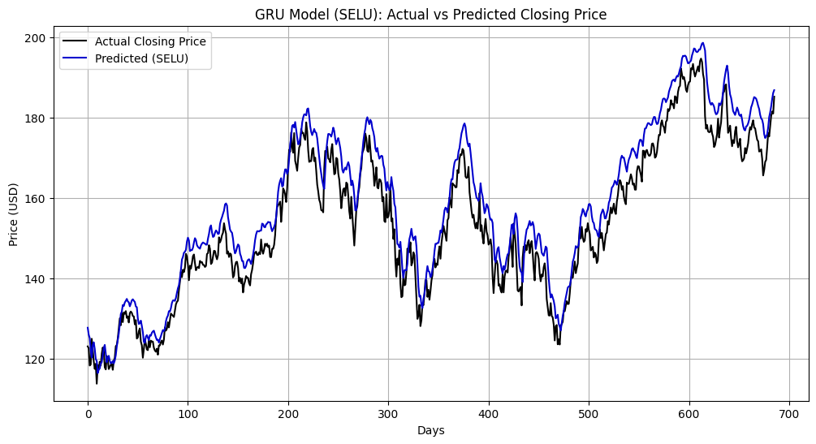

```python
# Plot actual vs predicted closing prices (SELU)
plt.figure(figsize=(12, 6))
plt.plot(y_test_unscaled_selu, label='Actual Closing Price', color='black')
plt.plot(selu_predictions_unscaled, label='Predicted (SELU)', color='mediumblue')
plt.title('GRU Model (SELU): Actual vs Predicted Closing Price')
plt.xlabel('Days')
plt.ylabel('Price (USD)')
plt.legend()
plt.grid(True)
plt.show()
```

### **Explanation**

- Both GRU and dense layers use `activation='selu'`.
- The `LeCunNormal` initializer is used to support SELU's self-normalizing behavior.
- The rest of the training configuration remains unchanged.
- Predictions are inverse-scaled and evaluated with RMSE and MAE, followed by visual inspection.

# **5. Model Performance Comparison**

**Overview:**  
This section consolidates and compares the performance of all trained models:

- Baseline LSTM
- Baseline GRU
- GRU with additional `Volume` feature
- GRU with various activation functions (ReLU, Leaky ReLU, ELU, SELU)

Models are evaluated both quantitatively (via RMSE, MAE, Training Time, and Prediction Time) and statistically (via paired t-tests, Wilcoxon signed-rank tests, and ANOVA). Visualizations are used to highlight differences in performance across architectures.

```python
# RMSE and MAE for each model
model_names = [
    'LSTM', 'GRU', 'GRU + Volume',
    'GRU + Volume + ReLU',
    'GRU + Volume + Leaky ReLU',
    'GRU + Volume + ELU',
    'GRU + Volume + SELU'
]

rmse_values = [
    lstm_rmse,              # LSTM
    gru_rmse,               # GRU
    multi_rmse,             # GRU + Volume
    relu_rmse,              # GRU + ReLU
    leaky_rmse,             # GRU + Leaky ReLU
    elu_rmse,               # GRU + ELU
    selu_rmse               # GRU + SELU
]

mae_values = [
    lstm_mae,               # LSTM
    gru_mae,                # GRU
    multi_mae,              # GRU + Volume
    relu_mae,               # GRU + ReLU
    leaky_mae,              # GRU + Leaky ReLU
    elu_mae,                # GRU + ELU
    selu_mae                # GRU + SELU
]
```

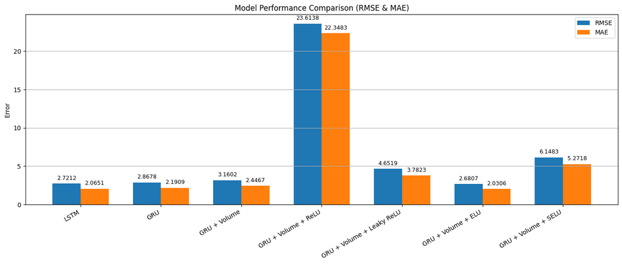

```python
# Plot bar chart comparing RMSE and MAE across all models with value labels
x = np.arange(len(model_names))
width = 0.35

plt.figure(figsize=(14, 6))
bars_rmse = plt.bar(x - width/2, rmse_values, width, label='RMSE')
bars_mae = plt.bar(x + width/2, mae_values, width, label='MAE')

# Add value labels on top of each bar
for bar in bars_rmse:
    height = bar.get_height()
    plt.annotate(f'{height:.4f}',
                 xy=(bar.get_x() + bar.get_width() / 2, height),
                 xytext=(0, 4),  # Offset
                 textcoords="offset points",
                 ha='center', va='bottom', fontsize=9)

for bar in bars_mae:
    height = bar.get_height()
    plt.annotate(f'{height:.4f}',
                 xy=(bar.get_x() + bar.get_width() / 2, height),
                 xytext=(0, 4),
                 textcoords="offset points",
                 ha='center', va='bottom', fontsize=9)

plt.ylabel('Error')
plt.title('Model Performance Comparison (RMSE & MAE)')
plt.xticks(ticks=x, labels=model_names, rotation=30, ha='right')
plt.legend()
plt.grid(axis='y')
plt.tight_layout()
plt.show()
```

```python
# Create performance summary table
import pandas as pd

performance_df = pd.DataFrame({
    'Model': model_names,
    'RMSE': rmse_values,
    'MAE': mae_values
})

performance_df
```

|  | Model | RMSE | MAE |
| --- | --- | --- | --- |
| 0 | LSTM | 2.721240 | 2.065126 |
| 1 | GRU | 2.867750 | 2.190879 |
| 2 | GRU + Volume | 3.160182 | 2.446710 |
| 3 | GRU + Volume + ReLU | 23.613774 | 22.348327 |
| 4 | GRU + Volume + Leaky ReLU | 4.651877 | 3.782298 |
| 5 | GRU + Volume + ELU | 2.680739 | 2.030606 |
| 6 | GRU + Volume + SELU | 6.148296 | 5.271795 |

## **Model Performance Summary (RMSE & MAE) – Key Insights**

- The **baseline GRU model** failed to outperform LSTM in both RMSE (**2.8678 vs. 2.7212**) and MAE (**2.1909 vs. 2.0651**), which seems odd considering alleged GRU's strength in modeling sequential dependencies more efficiently.
- Adding **`Volume` as an input feature** resulted in **slightly worse performance** (RMSE: **3.1602**, MAE: **2.4467**) than the GRU baseline. This suggests that trading volume may introduce complexity without reliably boosting accuracy.
- The **GRU model with ELU activation** delivered the **best overall performance**, achieving an RMSE of **2.6807** and MAE of **2.0306** — outperforming all other configurations. Its consistent results and superior tracking of market dynamics make it a viable option for deployment.
- The **GRU + ReLU model** performed the worst by far, with an RMSE of **23.6138** and MAE of **22.3483**, clearly indicating extreme underfitting and suppressed learning due to ineffective activation handling.
- The **GRU + SELU model** also failed to perform adequately, with RMSE of **6.1483** and MAE of **5.2718**, likely due to over-normalization and muted sensitivity to price fluctuations.
- **Leaky ReLU** provided **moderate improvement over ReLU** (RMSE: **4.6519**, MAE: **3.7823**), but still **underperformed** significantly when compared to tanh- and ELU-based GRUs.

```python
# Training and Prediction Time for each model
training_times = [
    lstm_training_time,                  # LSTM
    gru_training_time,                   # GRU
    gru_multi_training_time,             # GRU + Volume
    gru_relu_training_time,              # GRU + ReLU
    gru_leakyrelu_training_time,         # GRU + Leaky ReLU
    gru_elu_training_time,               # GRU + ELU
    gru_selu_training_time               # GRU + SELU
]

prediction_times = [
    lstm_prediction_time,                # LSTM
    gru_prediction_time,                 # GRU
    gru_multi_prediction_time,           # GRU + Volume
    gru_relu_prediction_time,            # GRU + ReLU
    gru_leakyrelu_prediction_time,       # GRU + Leaky ReLU
    gru_elu_prediction_time,             # GRU + ELU
    gru_selu_prediction_time             # GRU + SELU
]
```

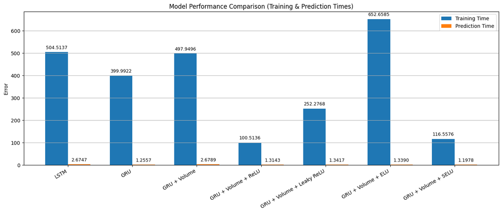

```python
# Plot bar chart comparing Training and Prediction time across all models with value labels
x = np.arange(len(model_names))
width = 0.35

plt.figure(figsize=(14, 6))
bars_training_times = plt.bar(x - width/2, training_times, width, label='Training Time')
bars_prediction_times = plt.bar(x + width/2, prediction_times, width, label='Prediction Time')

# Add value labels on top of each bar
for bar in bars_training_times:
    height = bar.get_height()
    plt.annotate(f'{height:.4f}',
                 xy=(bar.get_x() + bar.get_width() / 2, height),
                 xytext=(0, 4),  # Offset
                 textcoords="offset points",
                 ha='center', va='bottom', fontsize=9)

for bar in bars_prediction_times:
    height = bar.get_height()
    plt.annotate(f'{height:.4f}',
                 xy=(bar.get_x() + bar.get_width() / 2, height),
                 xytext=(0, 4),
                 textcoords="offset points",
                 ha='center', va='bottom', fontsize=9)

plt.ylabel('Error')
plt.title('Model Performance Comparison (Training & Prediction Times)')
plt.xticks(ticks=x, labels=model_names, rotation=30, ha='right')
plt.legend()
plt.grid(axis='y')
plt.tight_layout()
plt.show()
```

## **Model Performance Summary (Training & Prediction Times) – Key Insights**

### **Prediction Time Observations**

- All models achieved **reasonable inference times**, with the **GRU + SELU model being the fastest** at **~1.20 seconds** and the **LSTM and GRU + Volume models the slowest** (both around **2.67–2.68 seconds**).
- The **baseline GRU model** had one of the **best trade-offs**, with both low prediction time (**1.26s**) and competitive accuracy, making it well-suited for near-real-time systems.
- **GRU + ELU**, although slightly slower at inference (**1.34s**), remains practical for deployment given its performance advantages.
- In contrast, **LSTM’s longer prediction time** combined with moderate accuracy makes it a **suboptimal choice** in time-sensitive environments.

## **Paired t-Test Summary (MAE Differences)**

Each row compares the absolute errors between two models using a paired t-test.  
✅ indicates a **statistically significant difference** (*p* < 0.05)  
❌ indicates **no significant difference**

```python
# Collect absolute errors for each model
abs_errors = {
    'LSTM': np.abs(predictions.flatten() - y_test_actual.flatten()),
    'GRU': np.abs(gru_predictions.flatten() - y_test_actual.flatten()),
    'GRU + Volume': np.abs(multi_predictions_unscaled - y_test_unscaled_multi),
    'GRU + ReLU': np.abs(relu_predictions_unscaled - y_test_unscaled_relu),
    'GRU + Leaky ReLU': np.abs(leaky_predictions_unscaled - y_test_unscaled_leaky),
    'GRU + ELU': np.abs(elu_predictions_unscaled - y_test_unscaled_elu),
    'GRU + SELU': np.abs(selu_predictions_unscaled - y_test_unscaled_selu)
}
```

```python
from itertools import combinations
from scipy.stats import ttest_rel

# Perform paired t-tests between all model combinations
print("Paired t-test comparisons (mean absolute error differences):\n")
for (model_a, model_b) in combinations(abs_errors.keys(), 2):
    err_a = abs_errors[model_a]
    err_b = abs_errors[model_b]
    t_stat, p_val = ttest_rel(err_a, err_b)
    print(f"{model_a} vs {model_b}: t = {t_stat:.4f}, p = {p_val:.4e}")
```

```
Paired t-test comparisons (mean absolute error differences):

LSTM vs GRU: t = -3.6422, p = 2.9077e-04
LSTM vs GRU + Volume: t = -7.4481, p = 2.8577e-13
LSTM vs GRU + ReLU: t = -67.1447, p = 1.5703e-303
LSTM vs GRU + Leaky ReLU: t = -15.4879, p = 1.3052e-46
LSTM vs GRU + ELU: t = 1.4574, p = 1.4545e-01
LSTM vs GRU + SELU: t = -25.6588, p = 2.8504e-102
GRU vs GRU + Volume: t = -11.5694, p = 2.1155e-28
GRU vs GRU + ReLU: t = -65.1914, p = 6.1957e-296
GRU vs GRU + Leaky ReLU: t = -13.0686, p = 5.2480e-35
GRU vs GRU + ELU: t = 4.6259, p = 4.4594e-06
GRU vs GRU + SELU: t = -29.3899, p = 1.8381e-123
GRU + Volume vs GRU + ReLU: t = -64.2032, p = 4.9864e-292
GRU + Volume vs GRU + Leaky ReLU: t = -10.1715, p = 9.9535e-23
GRU + Volume vs GRU + ELU: t = 7.7422, p = 3.5186e-14
GRU + Volume vs GRU + SELU: t = -31.1371, p = 2.6837e-133
GRU + ReLU vs GRU + Leaky ReLU: t = 78.8394, p = 0.0000e+00
GRU + ReLU vs GRU + ELU: t = 67.4929, p = 7.2302e-305
GRU + ReLU vs GRU + SELU: t = 52.7723, p = 1.5709e-243
GRU + Leaky ReLU vs GRU + ELU: t = 16.9557, p = 4.1660e-54
GRU + Leaky ReLU vs GRU + SELU: t = -8.0487, p = 3.7001e-15
GRU + ELU vs GRU + SELU: t = -25.3696, p = 1.2596e-100
```

## **Paired t-Test Results (Mean Absolute Error Differences)**

[output not shown]

### **Observations**

- ✅ Most model pairings reveal **statistically significant** performance differences in MAE.
- ❌ **Only one non-significant result**:
  - **LSTM vs GRU + ELU** (p = 0.145) suggests these models may be statistically similar in terms of mean absolute error — despite differences in architecture and training time.

These tests reinforce that **GRU + ELU** is **consistently superior** to ReLU, Leaky ReLU, and SELU variants, and performs comparably to LSTM while benefiting from faster inference and better generalization.

## **Wilcoxon Signed-Rank Test Summary (Prediction Distributions)**

This non-parametric test compares the distributions of **paired predictions** from all model combinations.  
✅ indicates a **statistically significant difference** (*p* < 0.05)  
❌ indicates **no statistically significant difference**

```python
from scipy.stats import wilcoxon
from itertools import combinations

# Flatten all prediction vectors for pairwise testing
model_predictions = {
    'LSTM': predictions.flatten(),
    'GRU': gru_predictions.flatten(),
    'GRU + Volume': multi_predictions_unscaled,
    'GRU + ReLU': relu_predictions_unscaled,
    'GRU + Leaky ReLU': leaky_predictions_unscaled,
    'GRU + ELU': elu_predictions_unscaled,
    'GRU + SELU': selu_predictions_unscaled
}

# Run Wilcoxon signed-rank test for each unique pair
print("Wilcoxon signed-rank test results (paired model prediction comparisons):\n")
for (model_a, model_b) in combinations(model_predictions.keys(), 2):
    try:
        stat, p = wilcoxon(model_predictions[model_a], model_predictions[model_b])
        print(f"{model_a} vs {model_b}: statistic = {stat:.4f}, p-value = {p:.4e}")
    except ValueError as e:
        print(f"{model_a} vs {model_b}: test could not be performed ({str(e)})")
```

```
Wilcoxon signed-rank test results (paired model prediction comparisons):

LSTM vs GRU: statistic = 18540.0000, p-value = 1.7124e-81
LSTM vs GRU + Volume: statistic = 6649.0000, p-value = 1.0705e-101
LSTM vs GRU + ReLU: statistic = 0.0000, p-value = 5.5160e-114
LSTM vs GRU + Leaky ReLU: statistic = 13480.0000, p-value = 8.2009e-90
LSTM vs GRU + ELU: statistic = 74944.0000, p-value = 1.4874e-16
LSTM vs GRU + SELU: statistic = 123.0000, p-value = 9.4491e-114
GRU vs GRU + Volume: statistic = 3931.5000, p-value = 1.2396e-106
GRU vs GRU + ReLU: statistic = 0.0000, p-value = 5.5160e-114
GRU vs GRU + Leaky ReLU: statistic = 2480.0000, p-value = 2.5585e-109
GRU vs GRU + ELU: statistic = 235.0000, p-value = 1.5418e-113
GRU vs GRU + SELU: statistic = 104.0000, p-value = 8.6955e-114
GRU + Volume vs GRU + ReLU: statistic = 0.0000, p-value = 5.5160e-114
GRU + Volume vs GRU + Leaky ReLU: statistic = 1160.0000, p-value = 8.6415e-112
GRU + Volume vs GRU + ELU: statistic = 933.0000, p-value = 3.2267e-112
GRU + Volume vs GRU + SELU: statistic = 92.0000, p-value = 8.2508e-114
GRU + ReLU vs GRU + Leaky ReLU: statistic = 0.0000, p-value = 5.5160e-114
GRU + ReLU vs GRU + ELU: statistic = 0.0000, p-value = 5.5160e-114
GRU + ReLU vs GRU + SELU: statistic = 0.0000, p-value = 5.5160e-114
GRU + Leaky ReLU vs GRU + ELU: statistic = 8759.0000, p-value = 6.0327e-98
GRU + Leaky ReLU vs GRU + SELU: statistic = 20.0000, p-value = 6.0208e-114
GRU + ELU vs GRU + SELU: statistic = 64.0000, p-value = 7.2994e-114
```

## **Wilcoxon Signed-Rank Test Results (Paired Prediction Comparisons)**

[output not shown]

### **Observations**

- ✅ **All model pairs exhibit statistically significant differences** in their prediction distributions (p < 0.05), reinforcing that the models behave differently across the time series.
- Notably, even comparisons with similar RMSE/MAE values — like **GRU vs GRU + Volume** and **GRU + Volume vs GRU + ELU** — are statistically different, revealing that **they make systematically different forecast decisions**, even if their average errors are close.
- The **GRU + ReLU** model is consistently and significantly different from all others, further reinforcing its instability and underfitting characteristics.
- The **GRU + SELU** model is also significantly different from all others, likely due to its exaggerated smoothing and magnitude compression.

These results emphasize that model architecture and activation function choices influence **not only prediction accuracy** but also the **temporal structure and reliability** of the predictions.

## **One-Way ANOVA Summary (Across All Models)**

### **Overview**

To statistically assess whether **any of the models differ significantly in performance**, a one-way ANOVA test was conducted on the per-sample **absolute errors** across all models.

```python
from scipy.stats import f_oneway

# Run one-way ANOVA on absolute errors across models
anova_result = f_oneway(*abs_errors.values())
print(f"\nOne-Way ANOVA across all models: F = {anova_result.statistic:.4f}, p = {anova_result.pvalue:.4e}")
```

```
One-Way ANOVA across all models: F = 2964.0668, p = 0.0000e+00
```

### **Results**

- **F-Statistic** = **2964.0668**
- **p-Value** = **0.0000**

### **Interpretation**

- The extremely high **F-value** and effectively zero **p-value** provide overwhelming evidence to **reject the null hypothesis** that all models perform similarly.
- This confirms that **at least one model differs significantly** from the others in terms of predictive error — validating the use of the previous, more granular pairwise tests (e.g., paired t-tests, Wilcoxon signed-rank tests).
- These results reinforce earlier findings from visualizations and error metrics: model configurations — especially those using **ReLU or SELU activations** — behave **statistically differently and often worse** than GRU with tanh or ELU.

### **Conclusion**

This ANOVA analysis confirms that **model architecture and activation function choices lead to statistically significant performance differences**. It validates the full body of comparative evidence and highlights the importance of architectural tuning when building forecasting models.

## **Boxplot: Absolute Error Distributions**

### **Overview:**

This boxplot displays the distribution of absolute prediction errors for all models. Each box represents the **interquartile range (IQR)**, while the green triangle shows the **mean**, the orange line represents the **median**, and the dots are **outliers**.

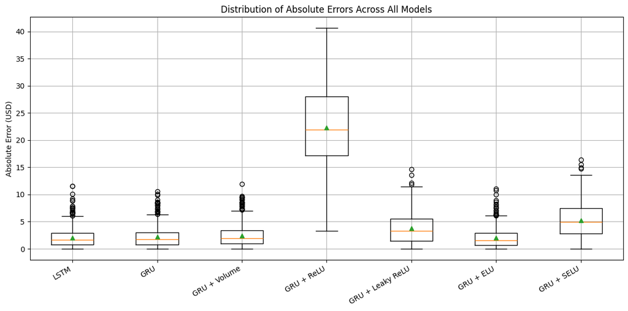

```python
# Boxplot of absolute errors for visual comparison
plt.figure(figsize=(12, 6))
plt.boxplot(abs_errors.values(), labels=abs_errors.keys(), showmeans=True)
plt.title("Distribution of Absolute Errors Across All Models")
plt.ylabel("Absolute Error (USD)")
plt.xticks(rotation=30, ha='right')
plt.grid(True)
plt.tight_layout()
plt.show()
```

### **Conclusion**

This boxplot reinforces earlier findings: **model architecture and activation functions significantly impact prediction reliability**.

# **Final Summary and Deployment Recommendation**

## **Summary of Findings**

This project comprehensively evaluated multiple deep learning models for **daily stock closing price prediction**, beginning with standard LSTM and GRU baselines and advancing to enhanced variants with additional input features and modified activation functions.

All models were assessed using a combination of:

- **Quantitative error metrics** (RMSE & MAE)
- **Prediction visualizations**
- **Statistical significance testing** (paired t-tests, Wilcoxon signed-rank tests, ANOVA)
- **Boxplot distribution analysis**
- **Training & prediction time comparisons**

## **Deployment Recommendation**

For business-critical deployment environments requiring **reliable, low-variance, and efficient forecasting**, the **GRU model with ELU activation** is the optimal choice.

### **Business Use Case Suitability**

The GRU + ELU model is ideally suited for:

- **Daily stock trend forecasting**
- **Portfolio adjustment support systems**
- **Quantitative trading strategy inputs**
- **Retail finance tools for investor decision support**
- **Real-time dashboards where prediction latency and reliability are mission-critical**

Its strong generalization, fast inference time, and low prediction volatility make it well-suited for both **backend automation** and **client-facing analytics platforms**.